# TSA Report

2023-06-01

```r
getwd()
```

```
## [1] "D:/UW/2. Summer 22-23/1. Time Series Analysis/Project/TSA"
```

## 1. Data Preparation

Load necessary packages to memory:

```r
library(xts)
library(tidyverse)
library(quantmod)
library(lmtest)
library(forecast)
library(dygraphs)
library(vars)
library(knitr)
library(kableExtra)
```

Load some pre-defined functions:

```r
source("testdf.R")
```

```r
source("function_plot_ACF_PACF_resids.R")
```

Load Dataset:

```r
Data <- read.csv("TSA_2023_project_data_1.csv",header = TRUE, dec = ".")
```

## 2 Summary Data

```r
str(Data)
```

```
## 'data.frame':    970 obs. of  11 variables:
##  $ X  : chr  "11-04-18" "12-04-18" "13-04-18" "14-04-18" ...
##  $ x1 : num  105 107 108 108 106 ...
##  $ x2 : num  110 110 109 108 108 ...
##  $ x3 : num  127 128 129 129 127 ...
##  $ x4 : num  117 115 117 117 117 ...
##  $ x5 : num  114 116 115 115 116 ...
##  $ x6 : num  147 147 146 147 148 ...
##  $ x7 : num  155 154 153 155 153 ...
##  $ x8 : num  189 191 188 189 190 ...
##  $ x9 : num  90.3 89.9 90.4 91 89.5 ...
##  $ x10: num  167 166 167 166 165 ...
```

Notice that the first column is the Date column, which is under “Character” type We need to transform it into “Date” type.

```r
Data$X <- as.Date(Data$X,
                  format = "%d-%m-%y")
```

Until now the class is “Data.Frame” object

```r
class(Data)
```

```
## [1] "data.frame"
```

Create xts objects

```r
Data <- xts(Data[,-1], Data$X)
```

After creating xts objects, the class is “xts”, “zoo”

```r
class(Data)
```

```
## [1] "xts" "zoo"
```

```r
str(Data)
```

```
## An 'xts' object on 2018-04-11/2020-12-05 containing:
##   Data: num [1:970, 1:10] 105 107 108 108 106 ...
##  - attr(*, "dimnames")=List of 2
##   ..$ : NULL
##   ..$ : chr [1:10] "x1" "x2" "x3" "x4" ...
##   Indexed by objects of class: [Date] TZ: UTC
##   xts Attributes:
##  NULL
```

```r
Data %>% glimpse()
```

```
## An 'xts' object on 2018-04-11/2020-12-05 containing:
##   Data: num [1:970, 1:10] 105 107 108 108 106 ...
##  - attr(*, "dimnames")=List of 2
##   ..$ : NULL
##   ..$ : chr [1:10] "x1" "x2" "x3" "x4" ...
##   Indexed by objects of class: [Date] TZ: UTC
##   xts Attributes:
##  NULL
```

Checking for missing data

```r
summary(Data)
```

```
##      Index                  x1               x2               x3
##  Min.   :2018-04-11   Min.   : 88.29   Min.   : 85.64   Min.   :124.2
##  1st Qu.:2018-12-09   1st Qu.: 95.46   1st Qu.: 92.81   1st Qu.:135.5
##  Median :2019-08-08   Median : 99.20   Median : 97.35   Median :141.3
##  Mean   :2019-08-08   Mean   :100.06   Mean   : 98.43   Mean   :139.9
##  3rd Qu.:2020-04-06   3rd Qu.:105.11   3rd Qu.:104.99   3rd Qu.:144.4
##  Max.   :2020-12-05   Max.   :111.07   Max.   :109.92   Max.   :150.4
##        x4               x5              x6              x7
##  Min.   : 85.19   Min.   :104.8   Min.   :142.5   Min.   :139.5
##  1st Qu.:108.19   1st Qu.:111.1   1st Qu.:152.1   1st Qu.:145.8
##  Median :115.68   Median :113.0   Median :155.5   Median :149.3
##  Mean   :114.87   Mean   :112.7   Mean   :154.8   Mean   :149.5
##  3rd Qu.:122.69   3rd Qu.:114.6   3rd Qu.:157.9   3rd Qu.:153.9
##  Max.   :141.62   Max.   :119.2   Max.   :165.0   Max.   :158.0
##        x8              x9              x10
##  Min.   :179.5   Min.   : 10.70   Min.   :151.5
##  1st Qu.:189.2   1st Qu.: 29.15   1st Qu.:156.5
##  Median :193.9   Median : 40.96   Median :158.8
##  Mean   :194.8   Mean   : 45.37   Mean   :159.4
##  3rd Qu.:199.1   3rd Qu.: 60.91   3rd Qu.:162.2
##  Max.   :219.3   Max.   :101.21   Max.   :170.3
```

```r
head(Data,6)
```

```
##                  x1       x2       x3       x4       x5       x6       x7
## 2018-04-11 105.3882 109.6174 127.0583 116.7108 114.2815 147.1509 155.0660
## 2018-04-12 107.1097 109.9211 128.0893 114.7180 115.5800 146.9616 154.3278
## 2018-04-13 108.2144 109.4070 129.4782 116.6820 114.9658 146.3560 152.8969
## 2018-04-14 108.0136 108.3335 128.7952 116.8109 114.5075 147.4023 154.6096
## 2018-04-15 106.4532 108.4117 127.0486 117.2085 116.3365 147.7198 153.1151
## 2018-04-16 107.6660 108.6879 127.1959 119.2785 113.8498 146.4102 153.6959
##                  x8       x9      x10
## 2018-04-11 189.3256 90.25521 167.4961
## 2018-04-12 190.7042 89.94702 166.1565
## 2018-04-13 188.0949 90.42754 166.6610
## 2018-04-14 188.9110 91.02123 166.1164
## 2018-04-15 190.1822 89.50997 164.7597
## 2018-04-16 188.1136 86.33956 165.1651
```

There is no missing data for the table.

##3. Checking for Cointegration

### Visualize the chart for all 10 time series.

Plot 10 Time Series together

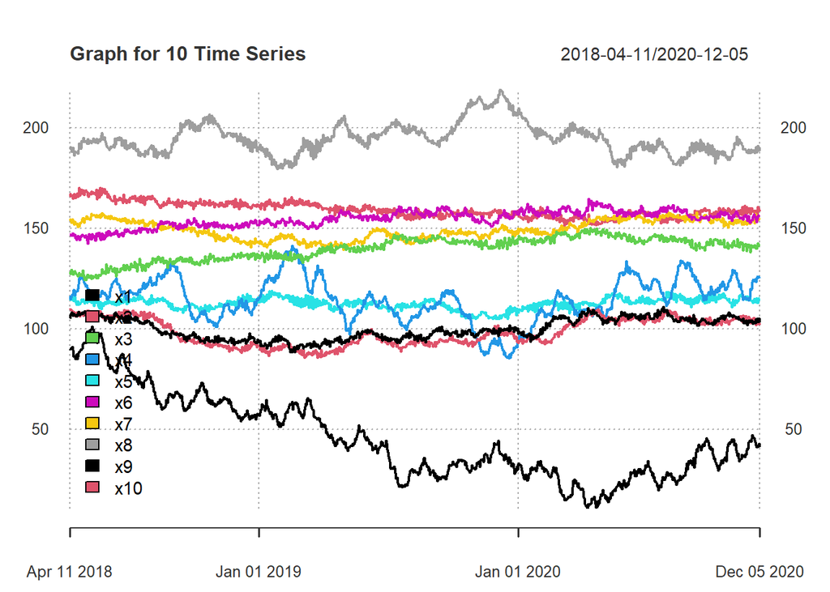

```r
plot(Data,
     main = "Graph for 10 Time Series",
     major.ticks = "years",
     grid.ticks.on = "years",
     grid.ticks.lty = 3,
     legend.loc = "bottomleft",
     type="l")
```

Plot 10 Time Series separately

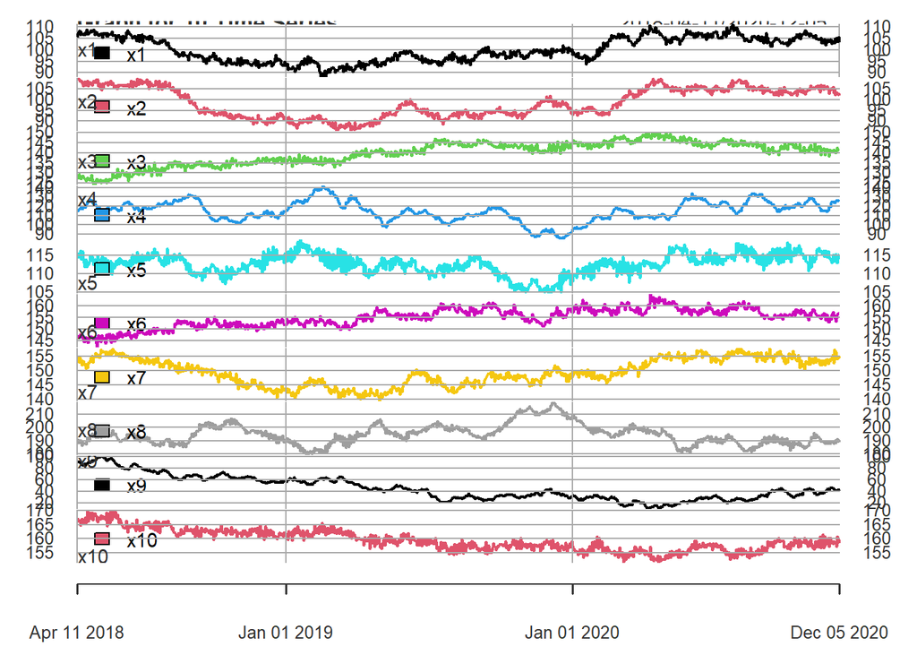

```r
plot(Data,
     main = "Graph for 10 Time Series",
     major.ticks = "years",
     grid.ticks.on = "years",
     legend.loc = "bottomleft",
     multi.panel = TRUE,
     yaxis.same = FALSE,
     type="l")
```

So our group decide to choose Time Series 1 and 2 for analysis.

### Create first difference

```r
Data$dx1 <- diff.xts(Data$x1)
Data$dx2 <- diff.xts(Data$x2)
```

Plot both variables on the graph:

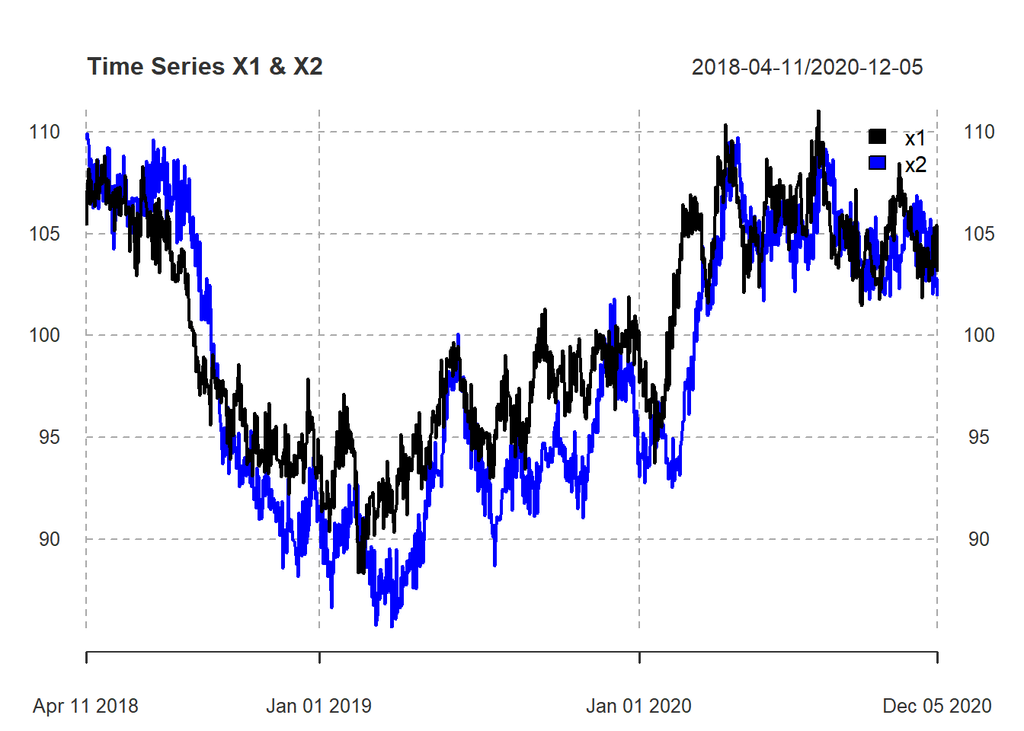

```r
plot(Data[, 1:2],
     col = c("black", "blue"),
     major.ticks = "years",
     grid.ticks.on = "years",
     grid.ticks.lty = 2,
     main = "Time Series X1 & X2",
     legend.loc = "topright")
```

### Testing cointegration We perform the tests of integration order.

Testing the order of the time series 1 and its difference:

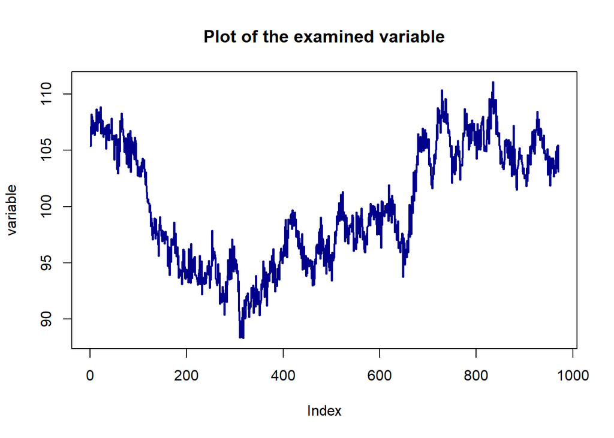

```
##   augmentations       adf     p_adf    bgodfrey         p_bg
## 1             0 -3.803259 0.0100000 264.5832974 1.719886e-59
## 2             1 -2.157827 0.2540868   2.0201728 1.552215e-01
## 3             2 -2.081606 0.2825813   0.3613083 5.477805e-01
## 4             3 -1.745467 0.4082435   0.9416019 3.318662e-01
```

```r
testdf(variable = Data$x1,
       max.augmentations = 3)
```

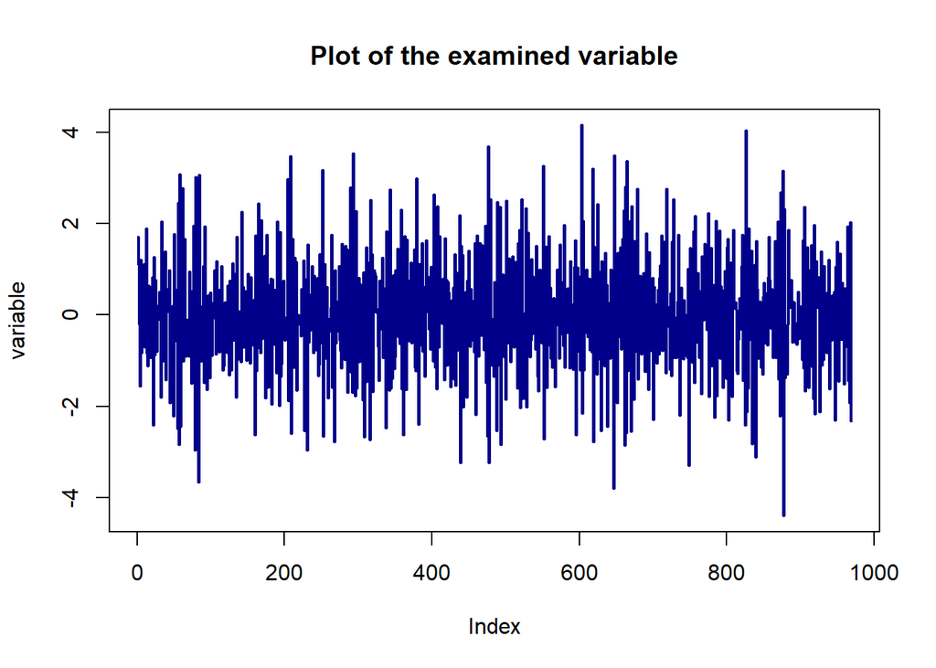

```
##   augmentations       adf p_adf  bgodfrey      p_bg
## 1             0 -57.26435  0.01 2.2435617 0.1341716
## 2             1 -29.78461  0.01 0.3975488 0.5283579
## 3             2 -27.06769  0.01 0.9268905 0.3356722
## 4             3 -17.77244  0.01 0.1955419 0.6583436
```

```r
testdf(variable = Data$dx1,
       max.augmentations = 3)
```

The p-bg is greater than 5% -> there are no auto-correlations in residual Next, we test the stationary of its 1st lag, by checking p-adf. p-adf is smaller than 5%. We can reject the null in the case of the first differences about non-stationary. Its 1st lag is stationary. We can conclude that the Time Series X1 is integrated of order 1.

Testing the order of the time series 2 and its difference:

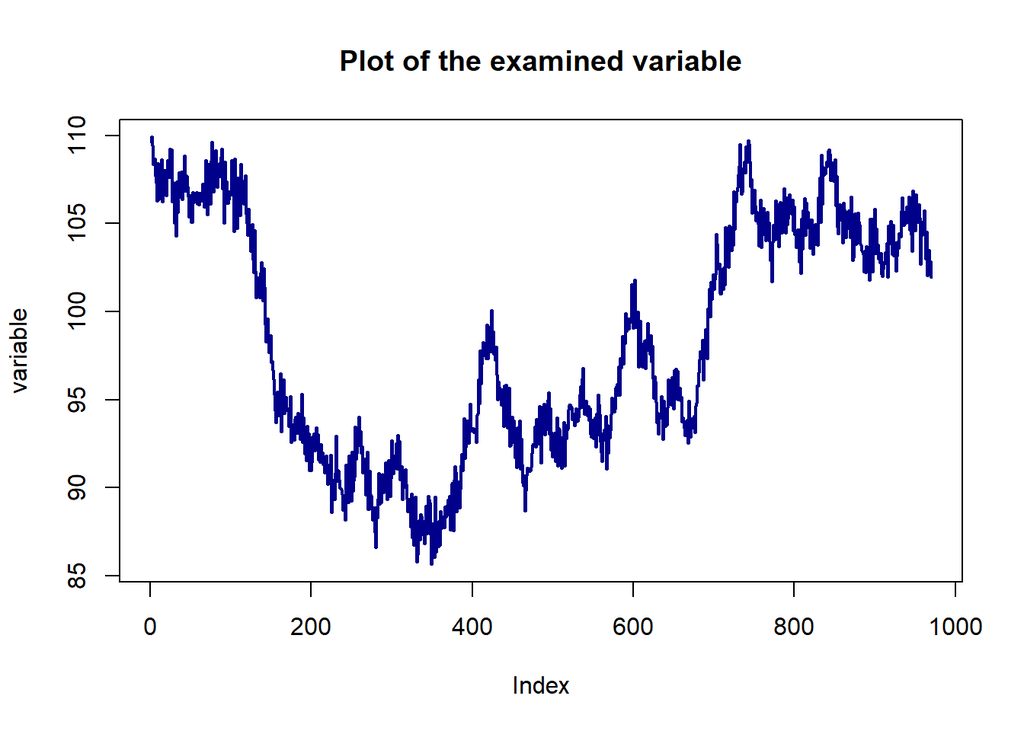

```
##   augmentations       adf      p_adf   bgodfrey         p_bg
## 1             0 -3.303984 0.01657912 264.339658 1.943586e-59
## 2             1 -2.084780 0.28139458   7.143669 7.522910e-03
## 3             2 -1.876867 0.35912092   2.241790 1.343254e-01
## 4             3 -1.578488 0.47066701   2.237972 1.346575e-01
```

```r
testdf(variable = Data$x2,
       max.augmentations = 3)
```

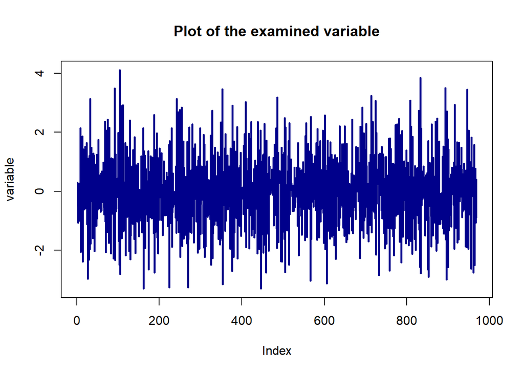

```
##   augmentations       adf p_adf  bgodfrey        p_bg
## 1             0 -56.64415  0.01 7.4813480 0.006234138
## 2             1 -32.10792  0.01 2.3416031 0.125959872
## 3             2 -30.35197  0.01 2.2137194 0.136788523
## 4             3 -18.39947  0.01 0.3831258 0.535935076
```

```r
testdf(variable = Data$dx2,
       max.augmentations = 3)
```

**Conclusion:** As a result, both variables has the same order 1: ∼I(1) so in the next step we can check whether they are cointegrated or not.

### Estimating the Cointegrated Vector:

```r
model.coint <- lm(x1 ~ x2, data = Data)
```

Examine the model summary:

```r
summary(model.coint)
```

```
##
## Call:
## lm(formula = x1 ~ x2, data = Data)
##
## Residuals:
##     Min      1Q  Median      3Q     Max
## -7.4048 -1.3505 -0.0383  1.2056  8.2950
##
## Coefficients:
##             Estimate Std. Error t value Pr(>|t|)
## (Intercept) 29.85349    1.07184   27.85   <2e-16 ***
## x2           0.71320    0.01086   65.65   <2e-16 ***
## ---
## Signif. codes:  0 '***' 0.001 '**' 0.01 '*' 0.05 '.' 0.1 ' ' 1
##
## Residual standard error: 2.263 on 968 degrees of freedom
## Multiple R-squared:  0.8166, Adjusted R-squared:  0.8164
## F-statistic:  4310 on 1 and 968 DF,  p-value: < 2.2e-16
```

Both the intercept and Coefficient for x2 are statistically significant.

The model is significantly explained by x2. We further test the stationary of the residuals:

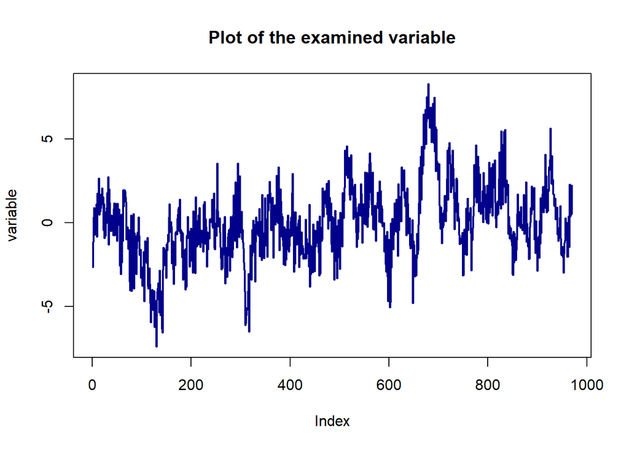

```
##   augmentations        adf p_adf   bgodfrey         p_bg
## 1             0 -11.911790  0.01 115.850425 5.125309e-27
## 2             1  -6.712962  0.01   3.173962 7.482073e-02
## 3             2  -5.768650  0.01   1.558156 2.119354e-01
## 4             3  -4.069538  0.01   2.124826 1.449292e-01
```

```r
testdf(variable = residuals(model.coint), max.augmentations = 3)
```

The cointegrating vector is [1, -29.853 , -0.713]

which defines the cointegrating relationship as: 1 * x1 - 29.853 - 0.713 * x2.

##4. Applying Box-Jenkins procedure:

###4.1 Applying for Time Series X1:

### Step 1: Model Parameters:

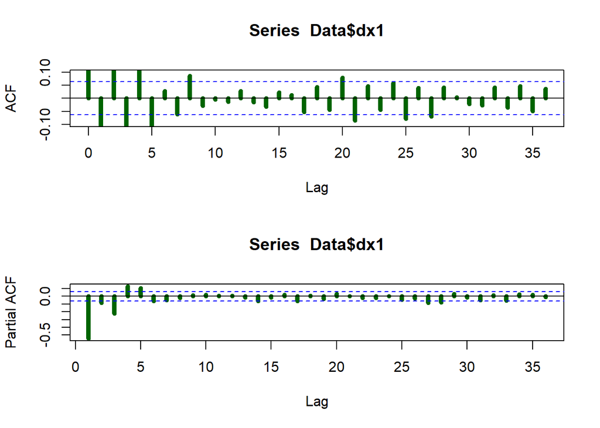

```r
par(mfrow = c(2, 1))
acf(Data$dx1,
    lag.max = 36, # max lag for ACF
    ylim = c(-0.1, 0.1),   # limits for the y axis - we give c(min, max)
    lwd = 5,
    col = "dark green",
    na.action = na.pass)   # do not stop if there are missing values in the data
pacf(Data$dx1,
     lag.max = 36,
     lwd = 5, col = "dark green",
     na.action = na.pass)
```

```r
par(mfrow = c(1, 1)) # restore the original single panel
```

The PACF shown is suggestive of an AR(5) model. So an initial candidate model is an ARIMA(5,1,0). We also have some variations of this model: ARIMA(5,1,1), ARIMA(4,1,0),ARIMA(3,1,0), ARIMA(3,1,3).

###Step 2 - model estimation

```r
arima510 <- Arima(Data$x1,  # variable
                  order = c(5, 1, 0)  # (p,d,q) parameters
)
```

```r
arima313 <- Arima(Data$x1,  # variable
                  order = c(3, 1, 3)  # (p,d,q) parameters
)
```

```r
coeftest(arima510)
```

```
##
## z test of coefficients:
##
##      Estimate Std. Error  z value  Pr(>|z|)
## ar1 -0.596241   0.032009 -18.6272 < 2.2e-16 ***
## ar2 -0.174508   0.036796  -4.7426 2.110e-06 ***
## ar3 -0.125306   0.037006  -3.3861 0.0007089 ***
## ar4  0.196671   0.036794   5.3453 9.028e-08 ***
## ar5  0.107940   0.032047   3.3682 0.0007566 ***
## ---
## Signif. codes:  0 '***' 0.001 '**' 0.01 '*' 0.05 '.' 0.1 ' ' 1
```

```r
summary(arima510)
```

```
## Series: Data$x1
## ARIMA(5,1,0)
##
## Coefficients:
##           ar1      ar2      ar3     ar4     ar5
##       -0.5962  -0.1745  -0.1253  0.1967  0.1079
## s.e.   0.0320   0.0368   0.0370  0.0368  0.0320
##
## sigma^2 = 1.036:  log likelihood = -1389.74
## AIC=2791.49   AICc=2791.58   BIC=2820.75
##
## Training set error measures:
##                        ME     RMSE       MAE          MPE      MAPE    MASE
## Training set -0.002458994 1.014519 0.8072381 -0.009472523 0.8093695 0.80967
##                     ACF1
## Training set 0.007764688
```

The above model is not included constant. Let’s include constant into the model:

```r
arima510_2 <- Arima(Data$x1,  # variable
                  order = c(5, 1, 0),  # (p,d,q) parameters
                  include.constant = TRUE)  # including a constant
```

```r
coeftest(arima510_2)
```

```
##
## z test of coefficients:
##
##         Estimate Std. Error  z value  Pr(>|z|)
## ar1   -0.5962591  0.0320094 -18.6276 < 2.2e-16 ***
## ar2   -0.1745463  0.0367977  -4.7434 2.102e-06 ***
## ar3   -0.1253417  0.0370070  -3.3870 0.0007067 ***
## ar4    0.1966395  0.0367945   5.3443 9.078e-08 ***
## ar5    0.1079200  0.0320471   3.3675 0.0007584 ***
## drift -0.0023145  0.0204875  -0.1130 0.9100535
## ---
## Signif. codes:  0 '***' 0.001 '**' 0.01 '*' 0.05 '.' 0.1 ' ' 1
```

Adding the constant did not change the result much, so we keep the model without constant

###Step 3 - model diagnostics Method 1:

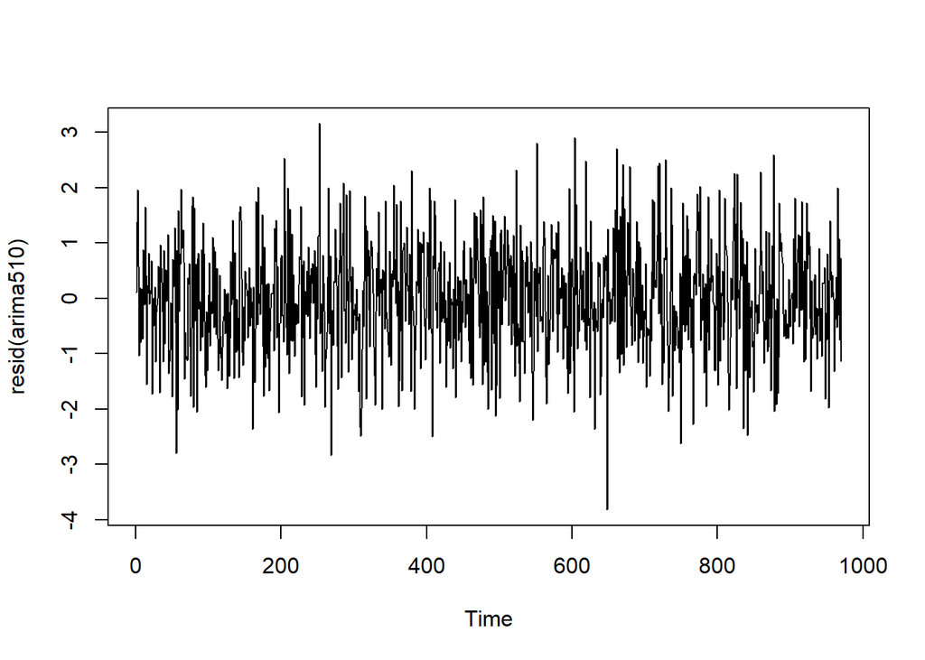

```r
plot(resid(arima510))
```

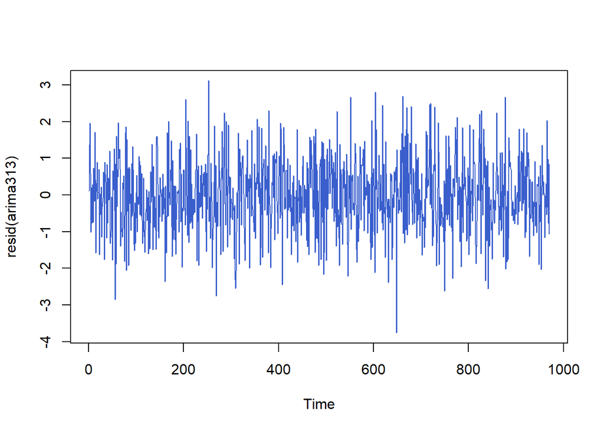

```r
plot(resid(arima313), col = "royalblue3")
```

Lets check the ACF and the PACF of the Residual values:

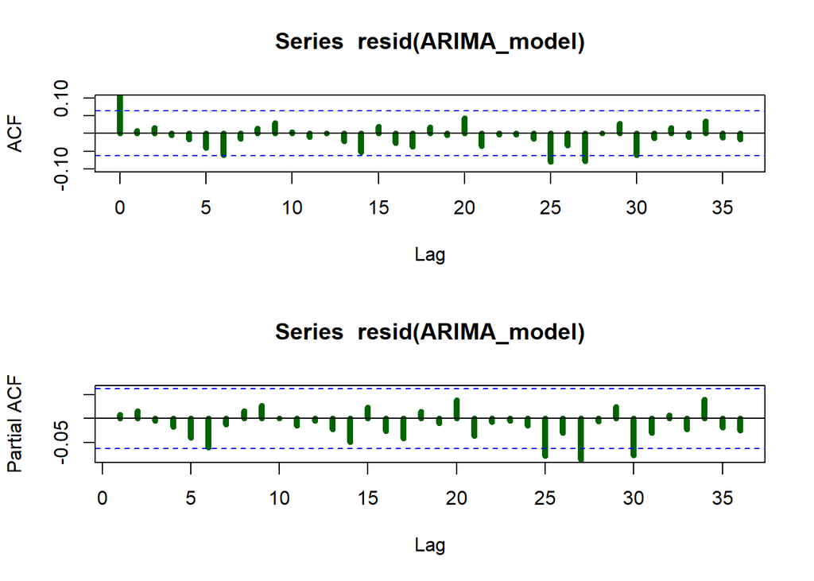

```r
plot_ACF_PACF_resids(arima510)
```

# The Ljung-Box test (for a maximum of 10 lags):

```r
Box.test(resid(arima510), type = "Ljung-Box", lag = 10)
```

```
##
##  Box-Ljung test
##
## data:  resid(arima510)
## X-squared = 7.0428, df = 10, p-value = 0.7214
```

```r
Box.test(resid(arima510), type = "Ljung-Box", lag = 15)
```

```
##
##  Box-Ljung test
##
## data:  resid(arima510)
## X-squared = 10.704, df = 15, p-value = 0.7733
```

```r
Box.test(resid(arima510), type = "Ljung-Box", lag = 20)
```

```
##
##  Box-Ljung test
##
## data:  resid(arima510)
## X-squared = 14.992, df = 20, p-value = 0.7768
```

```r
Box.test(resid(arima510), type = "Ljung-Box", lag = 25)
```

```
##
##  Box-Ljung test
##
## data:  resid(arima510)
## X-squared = 22.683, df = 25, p-value = 0.5961
```

```r
Box.test(resid(arima313), type = "Ljung-Box", lag = 10)
```

```
##
##  Box-Ljung test
##
## data:  resid(arima313)
## X-squared = 2.5635, df = 10, p-value = 0.9899
```

```r
Box.test(resid(arima313), type = "Ljung-Box", lag = 15)
```

```
##
##  Box-Ljung test
##
## data:  resid(arima313)
## X-squared = 5.8069, df = 15, p-value = 0.9828
```

```r
Box.test(resid(arima313), type = "Ljung-Box", lag = 20)
```

```
##
##  Box-Ljung test
##
## data:  resid(arima313)
## X-squared = 10.277, df = 20, p-value = 0.9629
```

```r
Box.test(resid(arima313), type = "Ljung-Box", lag = 25)
```

```
##
##  Box-Ljung test
##
## data:  resid(arima313)
## X-squared = 18.939, df = 25, p-value = 0.8001
```

-> Very large p-values: The residual is white-noise

Plot graph for Ljung-Box test:

```r
bj_pvalues = c()
```

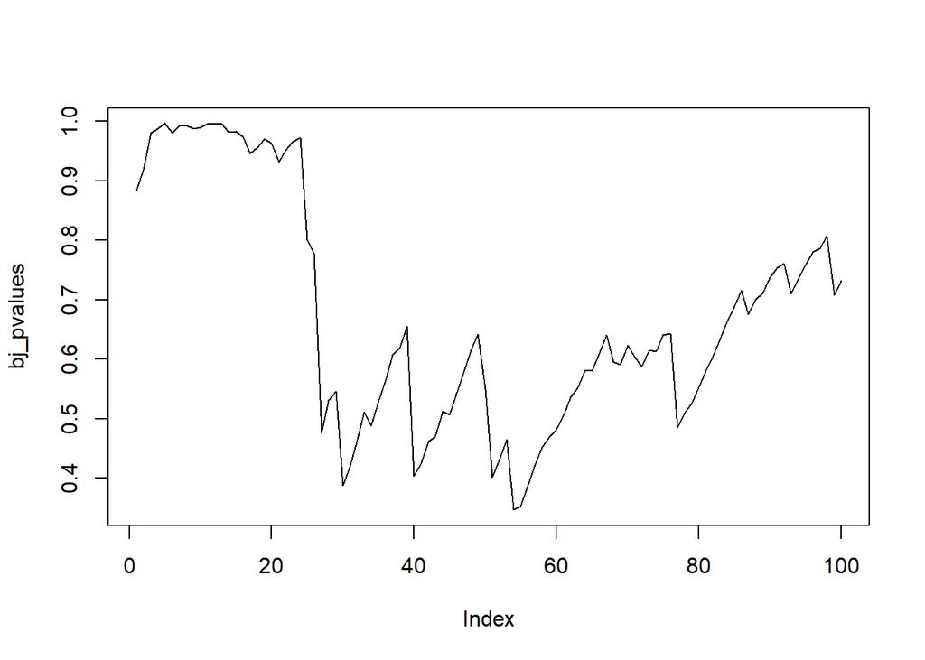

```r
for(i in c(1:100)){
  bj = Box.test(resid(arima313), type = "Ljung-Box", lag = i)
  bj_pvalues = append(bj_pvalues,bj$p.value)
}

plot(bj_pvalues, type='l')

abline(h = 0.05, col='red')
```

Model ARIMA(5,1,1)

```r
arima511 <- Arima(Data$x1,  # variable
                    order = c(5, 1, 1),  # (p,d,q) parameters
                    include.constant = TRUE)  # including a constant
```

```r
coeftest(arima511)
```

```
##
## z test of coefficients:
##
##         Estimate Std. Error z value  Pr(>|z|)
## ar1   -0.8524455  0.2051943 -4.1543 3.262e-05 ***
## ar2   -0.3229332  0.1264040 -2.5548 0.0106258 *
## ar3   -0.1733121  0.0583427 -2.9706 0.0029723 **
## ar4    0.1611500  0.0533885  3.0184 0.0025408 **
## ar5    0.1453997  0.0381957  3.8067 0.0001408 ***
## ma1    0.2592500  0.2061939  1.2573 0.2086408
## drift -0.0023359  0.0200933 -0.1163 0.9074527
## ---
## Signif. codes:  0 '***' 0.001 '**' 0.01 '*' 0.05 '.' 0.1 ' ' 1
```

ARIMA(4,1,0)

```r
arima410 <- Arima(Data$x1,  # variable
                  order = c(4, 1, 0),  # (p,d,q) parameters
                  include.constant = TRUE)  # including a constant
```

```r
coeftest(arima410)
```

```
##
## z test of coefficients:
##
##         Estimate Std. Error  z value  Pr(>|z|)
## ar1   -0.5819000  0.0319116 -18.2348 < 2.2e-16 ***
## ar2   -0.1898848  0.0367345  -5.1691 2.352e-07 ***
## ar3   -0.1457418  0.0367273  -3.9682 7.241e-05 ***
## ar4    0.1341308  0.0319590   4.1970 2.705e-05 ***
## drift -0.0024076  0.0184004  -0.1308    0.8959
## ---
## Signif. codes:  0 '***' 0.001 '**' 0.01 '*' 0.05 '.' 0.1 ' ' 1
```

ARIMA(3,1,0).

```r
arima310 <- Arima(Data$x1,  # variable
                  order = c(3, 1, 0),  # (p,d,q) parameters
                  include.constant = TRUE)  # including a constant
```

```r
coeftest(arima310)
```

```
##
## z test of coefficients:
##
##         Estimate Std. Error  z value  Pr(>|z|)
## ar1   -0.6118793  0.0313858 -19.4954 < 2.2e-16 ***
## ar2   -0.2191582  0.0364032  -6.0203 1.741e-09 ***
## ar3   -0.2275469  0.0314098  -7.2445 4.342e-13 ***
## drift -0.0024947  0.0160914  -0.1550    0.8768
## ---
## Signif. codes:  0 '***' 0.001 '**' 0.01 '*' 0.05 '.' 0.1 ' ' 1
```

###Step 4. Evaluate Model:

```r
AIC(arima510,arima510_2, arima511, arima410, arima310, arima313)
```

```
##            df      AIC
## arima510    6 2791.488
## arima510_2  7 2793.475
## arima511    8 2793.948
## arima410    6 2802.745
## arima310    5 2818.194
## arima313    7 2789.785
```

```r
BIC(arima510, arima510_2, arima511, arima410, arima310, arima313)
```

```
##            df      BIC
## arima510    6 2820.745
## arima510_2  7 2827.609
## arima511    8 2832.958
## arima410    6 2832.003
## arima310    5 2842.575
## arima313    7 2823.919
```

-> Suggestion ARIMA(3,1,3)

#Cross check with Auto Correlation:

```r
arima.best.AIC <-
  auto.arima(Data$x1,
             d = 1,             # parameter d of ARIMA model
             max.p = 6,         # Maximum value of p
             max.q = 6,         # Maximum value of q
             max.order = 12,    # maximum p+q
             start.p = 1,       # Starting value of p in stepwise procedure
             start.q = 1,       # Starting value of q in stepwise procedure
             ic = "aic",        # Information criterion to be used in model selection.
             stepwise = FALSE,  # if FALSE considers all models
             allowdrift = TRUE, # include a constant
             trace = TRUE)      # show summary of all models considered
```

```
##
##  Fitting models using approximations to speed things up...
##
##  ARIMA(0,1,0)                    : 3209.261
##  ARIMA(0,1,0) with drift         : 3211.258
##  ARIMA(0,1,1)                    : 2892.22
##  ARIMA(0,1,1) with drift         : 2894.201
##  ARIMA(0,1,2)                    : 2860.792
##  ARIMA(0,1,2) with drift         : 2862.78
##  ARIMA(0,1,3)                    : 2862.759
##  ARIMA(0,1,3) with drift         : 2864.747
##  ARIMA(0,1,4)                    : 2835.093
##  ARIMA(0,1,4) with drift         : 2837.086
##  ARIMA(0,1,5)                    : 2792.617
##  ARIMA(0,1,5) with drift         : 2794.603
##  ARIMA(0,1,6)                    : 2794.509
##  ARIMA(0,1,6) with drift         : 2796.495
##  ARIMA(1,1,0)                    : 2868.53
##  ARIMA(1,1,0) with drift         : 2870.515
##  ARIMA(1,1,1)                    : 2853.523
##  ARIMA(1,1,1) with drift         : 2855.494
##  ARIMA(1,1,2)                    : 2832.1
##  ARIMA(1,1,2) with drift         : 2834.079
##  ARIMA(1,1,3)                    : 2833.996
##  ARIMA(1,1,3) with drift         : 2835.975
##  ARIMA(1,1,4)                    : 2805.463
##  ARIMA(1,1,4) with drift         : 2807.448
##  ARIMA(1,1,5)                    : 2789.916
##  ARIMA(1,1,5) with drift         : 2791.876
##  ARIMA(1,1,6)                    : 2790.914
##  ARIMA(1,1,6) with drift         : 2792.863
##  ARIMA(2,1,0)                    : 2860.905
##  ARIMA(2,1,0) with drift         : 2862.868
##  ARIMA(2,1,1)                    : 2851.992
##  ARIMA(2,1,1) with drift         : 2853.936
##  ARIMA(2,1,2)                    : 2831.94
##  ARIMA(2,1,2) with drift         : 2833.896
##  ARIMA(2,1,3)                    : 2830.689
##  ARIMA(2,1,3) with drift         : 2832.635
##  ARIMA(2,1,4)                    : 2800.098
```

[output cut: 53 more lines]

```
##  ARIMA(6,1,3)                    : 2790.445
##  ARIMA(6,1,3) with drift         : 2792.415
##  ARIMA(6,1,4)                    : 2792.372
##  ARIMA(6,1,4) with drift         : 2794.339
##  ARIMA(6,1,5)                    : 2794.369
##  ARIMA(6,1,5) with drift         : 2796.336
##  ARIMA(6,1,6)                    : 2795.546
##  ARIMA(6,1,6) with drift         : 2797.527
##
##  Now re-fitting the best model(s) without approximations...
##
##
##
##
##  Best model: ARIMA(4,1,2)
```

Return: Best model: ARIMA(4,1,2)

```r
arima412 <- Arima(Data$x1,  # variable
                  order = c(4, 1, 2),  # (p,d,q) parameters
                  include.constant = TRUE)  # including a constant
```

```r
coeftest(arima412)
```

```
##
## z test of coefficients:
##
##         Estimate Std. Error z value  Pr(>|z|)
## ar1   -0.4097072  0.1619528 -2.5298 0.0114129 *
## ar2   -0.4275352  0.1502445 -2.8456 0.0044328 **
## ar3   -0.3085716  0.0813635 -3.7925 0.0001491 ***
## ar4    0.1487375  0.0552176  2.6937 0.0070672 **
## ma1   -0.1839428  0.1622059 -1.1340 0.2567911
## ma2    0.3747284  0.0923050  4.0597 4.914e-05 ***
## drift -0.0023734  0.0194023 -0.1223 0.9026406
## ---
## Signif. codes:  0 '***' 0.001 '**' 0.01 '*' 0.05 '.' 0.1 ' ' 1
```

```r
AIC(arima313,arima412)
```

```
##          df      AIC
## arima313  7 2789.785
## arima412  8 2790.814
```

```r
BIC(arima313,arima412)
```

```
##          df      BIC
## arima313  7 2823.919
## arima412  8 2829.824
```

Check for BIC best:

```r
arima.best.BIC <-
  auto.arima(Data$x1,
             d = 1,             # parameter d of ARIMA model
             max.p = 6,         # Maximum value of p
             max.q = 6,         # Maximum value of q
             max.order = 12,    # maximum p+q
             start.p = 1,       # Starting value of p in stepwise procedure
             start.q = 1,       # Starting value of q in stepwise procedure
             ic = "bic",        # Information criterion to be used in model selection.
             stepwise = FALSE,  # if FALSE considers all models
             allowdrift = TRUE, # include a constant
             trace = TRUE)      # show summary of all models considered
```

```
##
##  Fitting models using approximations to speed things up...
##
##  ARIMA(0,1,0)                    : 3214.137
##  ARIMA(0,1,0) with drift         : 3221.01
##  ARIMA(0,1,1)                    : 2901.973
##  ARIMA(0,1,1) with drift         : 2908.83
##  ARIMA(0,1,2)                    : 2875.421
##  ARIMA(0,1,2) with drift         : 2882.285
##  ARIMA(0,1,3)                    : 2882.264
##  ARIMA(0,1,3) with drift         : 2889.129
##  ARIMA(0,1,4)                    : 2859.475
##  ARIMA(0,1,4) with drift         : 2866.344
##  ARIMA(0,1,5)                    : 2821.875
##  ARIMA(0,1,5) with drift         : 2828.736
##  ARIMA(0,1,6)                    : 2828.642
##  ARIMA(0,1,6) with drift         : 2835.505
##  ARIMA(1,1,0)                    : 2878.282
##  ARIMA(1,1,0) with drift         : 2885.144
##  ARIMA(1,1,1)                    : 2868.152
##  ARIMA(1,1,1) with drift         : 2874.999
##  ARIMA(1,1,2)                    : 2851.605
##  ARIMA(1,1,2) with drift         : 2858.461
##  ARIMA(1,1,3)                    : 2858.377
##  ARIMA(1,1,3) with drift         : 2865.232
##  ARIMA(1,1,4)                    : 2834.72
##  ARIMA(1,1,4) with drift         : 2841.582
##  ARIMA(1,1,5)                    : 2824.05
##  ARIMA(1,1,5) with drift         : 2830.886
##  ARIMA(1,1,6)                    : 2829.924
##  ARIMA(1,1,6) with drift         : 2836.749
##  ARIMA(2,1,0)                    : 2875.533
##  ARIMA(2,1,0) with drift         : 2882.373
##  ARIMA(2,1,1)                    : 2871.497
##  ARIMA(2,1,1) with drift         : 2878.318
##  ARIMA(2,1,2)                    : 2856.321
##  ARIMA(2,1,2) with drift         : 2863.154
##  ARIMA(2,1,3)                    : 2859.947
##  ARIMA(2,1,3) with drift         : 2866.769
##  ARIMA(2,1,4)                    : 2834.232
```

[output cut: 53 more lines]

```
##  ARIMA(6,1,3)                    : 2839.208
##  ARIMA(6,1,3) with drift         : 2846.053
##  ARIMA(6,1,4)                    : 2846.011
##  ARIMA(6,1,4) with drift         : 2852.854
##  ARIMA(6,1,5)                    : 2852.885
##  ARIMA(6,1,5) with drift         : 2859.727
##  ARIMA(6,1,6)                    : 2858.938
##  ARIMA(6,1,6) with drift         : 2865.795
##
##  Now re-fitting the best model(s) without approximations...
##
##
##
##
##  Best model: ARIMA(3,1,2)
```

Return: Best model: ARIMA(3,1,2)

```r
arima312 <- Arima(Data$x1,  # variable
                  order = c(3, 1, 2),  # (p,d,q) parameters
                  include.constant = TRUE)  # including a constant
```

```r
coeftest(arima312)
```

```
##
## z test of coefficients:
##
##         Estimate Std. Error  z value  Pr(>|z|)
## ar1   -0.7905145  0.0897303  -8.8099 < 2.2e-16 ***
## ar2   -0.7697690  0.0745102 -10.3311 < 2.2e-16 ***
## ar3   -0.4890744  0.0407454 -12.0032 < 2.2e-16 ***
## ma1    0.1848474  0.0989984   1.8672   0.06188 .
## ma2    0.4699417  0.0881270   5.3325 9.684e-08 ***
## drift -0.0024516  0.0177048  -0.1385   0.88987
## ---
## Signif. codes:  0 '***' 0.001 '**' 0.01 '*' 0.05 '.' 0.1 ' ' 1
```

```r
AIC(arima313,arima412,arima312)
```

```
##          df      AIC
## arima313  7 2789.785
## arima412  8 2790.814
## arima312  7 2793.412
```

```r
BIC(arima313,arima412,arima312)
```

```
##          df      BIC
## arima313  7 2823.919
## arima412  8 2829.824
## arima312  7 2827.546
```

*Conclusion:* ARIMA(3,1,3) for forcasting Time Series X1.

###4.1 Applying Box-Jenkins procedure for Time Series X2:

## Step 1: Model Parameters:

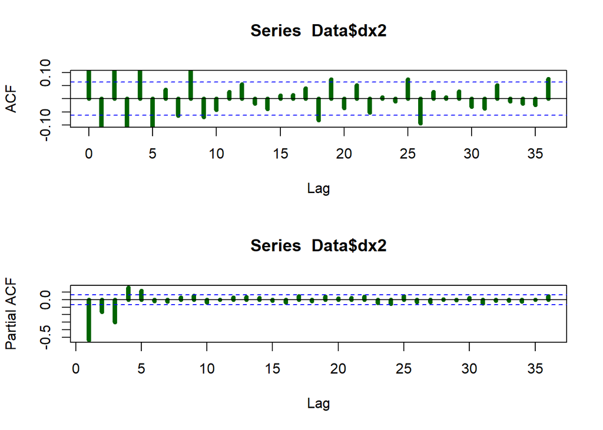

```r
par(mfrow = c(2, 1))
acf(Data$dx2,
    lag.max = 36, # max lag for ACF
    ylim = c(-0.1, 0.1),   # limits for the y axis - we give c(min, max)
    lwd = 5,
    col = "dark green",
    na.action = na.pass)   # do not stop if there are missing values in the data
pacf(Data$dx2,
     lag.max = 36,
     lwd = 5, col = "dark green",
     na.action = na.pass)
```

```r
par(mfrow = c(1, 1)) # restore the original single panel
```

The PACF shown is suggestive of an AR(5) model. So an initial candidate model is an ARIMA(5,1,0). We also have some variations of this model: ARIMA(5,1,1), ARIMA(4,1,0),ARIMA(3,1,0).

##Step 2 - model estimation

```r
arima510_x2 <- Arima(Data$x2,  # variable
                  order = c(5, 1, 0)  # (p,d,q) parameters
)
coeftest(arima510_x2)
```

```
##
## z test of coefficients:
##
##      Estimate Std. Error  z value  Pr(>|z|)
## ar1 -0.644866   0.031897 -20.2169 < 2.2e-16 ***
## ar2 -0.269632   0.037238  -7.2408 4.462e-13 ***
## ar3 -0.152155   0.037949  -4.0095 6.084e-05 ***
## ar4  0.239044   0.037248   6.4176 1.385e-10 ***
## ar5  0.121498   0.031871   3.8122 0.0001377 ***
## ---
## Signif. codes:  0 '***' 0.001 '**' 0.01 '*' 0.05 '.' 0.1 ' ' 1
```

```r
summary(arima510_x2)
```

```
## Series: Data$x2
## ARIMA(5,1,0)
##
## Coefficients:
##           ar1      ar2      ar3     ar4     ar5
##       -0.6449  -0.2696  -0.1522  0.2390  0.1215
## s.e.   0.0319   0.0372   0.0379  0.0372  0.0319
##
## sigma^2 = 1.069:  log likelihood = -1405.05
## AIC=2822.1   AICc=2822.19   BIC=2851.36
##
## Training set error measures:
##                       ME     RMSE       MAE         MPE      MAPE      MASE
## Training set -0.01266675 1.030568 0.8275789 -0.01979578 0.8444116 0.7749632
##                     ACF1
## Training set 0.001678718
```

The above model is not included constant. Let’s include constant into the model:

```r
arima510_2_x2 <- Arima(Data$x2,  # variable
                    order = c(5, 1, 0),  # (p,d,q) parameters
                    include.constant = TRUE)  # including a constant

coeftest(arima510_2_x2)
```

```
##
## z test of coefficients:
##
##         Estimate Std. Error  z value  Pr(>|z|)
## ar1   -0.6450303  0.0318974 -20.2220 < 2.2e-16 ***
## ar2   -0.2699057  0.0372415  -7.2474 4.247e-13 ***
## ar3   -0.1524278  0.0379516  -4.0164 5.910e-05 ***
## ar4    0.2387845  0.0372511   6.4101 1.454e-10 ***
## ar5    0.1213496  0.0318704   3.8076 0.0001403 ***
## drift -0.0076843  0.0194016  -0.3961 0.6920554
## ---
## Signif. codes:  0 '***' 0.001 '**' 0.01 '*' 0.05 '.' 0.1 ' ' 1
```

Adding the constant did not change the result much, so we keep the model without constant

##Step 3 - model diagnostics Method 1:

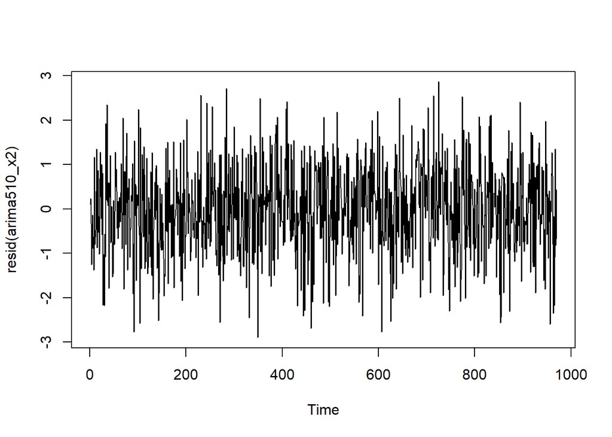

```r
plot(resid(arima510_x2))
```

The Ljung-Box test (for a maximum of 10 lags):

```r
Box.test(resid(arima510_x2), type = "Ljung-Box", lag = 10)
```

```
##
##  Box-Ljung test
##
## data:  resid(arima510_x2)
## X-squared = 2.6884, df = 10, p-value = 0.9878
```

```r
Box.test(resid(arima510_x2), type = "Ljung-Box", lag = 15)
```

```
##
##  Box-Ljung test
##
## data:  resid(arima510_x2)
## X-squared = 8.8657, df = 15, p-value = 0.8844
```

```r
Box.test(resid(arima510_x2), type = "Ljung-Box", lag = 20)
```

```
##
##  Box-Ljung test
##
## data:  resid(arima510_x2)
## X-squared = 16.452, df = 20, p-value = 0.6882
```

```r
Box.test(resid(arima510_x2), type = "Ljung-Box", lag = 25)
```

```
##
##  Box-Ljung test
##
## data:  resid(arima510_x2)
## X-squared = 19.863, df = 25, p-value = 0.754
```

-> Very large p-values: The residual is white-noise

Plot graph for Ljung-Box test:

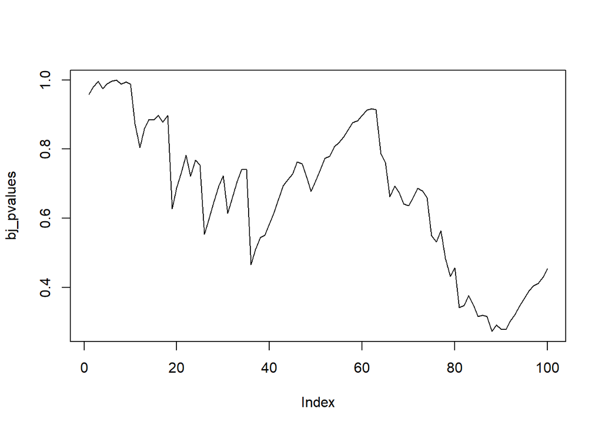

```r
bj_pvalues = c()

for(i in c(1:100)){
  bj = Box.test(resid(arima510_x2), type = "Ljung-Box", lag = i)
  bj_pvalues = append(bj_pvalues,bj$p.value)
}

plot(bj_pvalues, type='l')

abline(h=0.05, col='red')
```

Model ARIMA(5,1,1)

```r
arima511_x2 <- Arima(Data$x2,  # variable
                  order = c(5, 1, 1),  # (p,d,q) parameters
                  include.constant = TRUE)  # including a constant
```

```r
coeftest(arima511_x2)
```

```
##
## z test of coefficients:
##
##         Estimate Std. Error z value  Pr(>|z|)
## ar1   -0.7516457  0.2101252 -3.5771 0.0003474 ***
## ar2   -0.3364564  0.1364192 -2.4663 0.0136501 *
## ar3   -0.1835448  0.0737899 -2.4874 0.0128682 *
## ar4    0.2189786  0.0566813  3.8633 0.0001119 ***
## ar5    0.1390674  0.0445016  3.1250 0.0017781 **
## ma1    0.1081613  0.2111889  0.5122 0.6085432
## drift -0.0076447  0.0191803 -0.3986 0.6902112
## ---
## Signif. codes:  0 '***' 0.001 '**' 0.01 '*' 0.05 '.' 0.1 ' ' 1
```

ARIMA(4,1,0)

```r
arima410_x2 <- Arima(Data$x2,  # variable
                  order = c(4, 1, 0),  # (p,d,q) parameters
                  include.constant = TRUE)  # including a constant
```

```r
coeftest(arima410_x2)
```

```
##
## z test of coefficients:
##
##         Estimate Std. Error  z value  Pr(>|z|)
## ar1   -0.6251040  0.0317030 -19.7175 < 2.2e-16 ***
## ar2   -0.2927901  0.0370359  -7.9056 2.667e-15 ***
## ar3   -0.1881141  0.0370580  -5.0762 3.851e-07 ***
## ar4    0.1626762  0.0316745   5.1359 2.808e-07 ***
## drift -0.0075177  0.0171814  -0.4375    0.6617
## ---
## Signif. codes:  0 '***' 0.001 '**' 0.01 '*' 0.05 '.' 0.1 ' ' 1
```

ARIMA(3,1,0).

```r
arima310_x2 <- Arima(Data$x2,  # variable
                  order = c(3, 1, 0),  # (p,d,q) parameters
                  include.constant = TRUE)  # including a constant

coeftest(arima310_x2)
```

```
##
## z test of coefficients:
##
##         Estimate Std. Error  z value Pr(>|z|)
## ar1   -0.6737755  0.0306661 -21.9714   <2e-16 ***
## ar2   -0.3500612  0.0358073  -9.7763   <2e-16 ***
## ar3   -0.2980649  0.0306566  -9.7227   <2e-16 ***
## drift -0.0072772  0.0145811  -0.4991   0.6177
## ---
## Signif. codes:  0 '***' 0.001 '**' 0.01 '*' 0.05 '.' 0.1 ' ' 1
```

##Step 4. Evaluate Model:

```r
AIC(arima510_x2,arima510_2_x2, arima511_x2, arima410_x2, arima310_x2)
```

```
##               df      AIC
## arima510_x2    6 2822.100
## arima510_2_x2  7 2823.943
## arima511_x2    8 2825.688
## arima410_x2    6 2836.327
## arima310_x2    5 2860.337
```

```r
BIC(arima510_x2, arima510_2_x2, arima511_x2, arima410_x2, arima310_x2)
```

```
##               df      BIC
## arima510_x2    6 2851.357
## arima510_2_x2  7 2858.077
## arima511_x2    8 2864.698
## arima410_x2    6 2865.585
## arima310_x2    5 2884.718
```

-> Suggestion model: arima510_x2 - ARIMA(5,1,0)

Cross check with Auto Correlation:

```r
arima.best.AIC <-
  auto.arima(Data$x2,
             d = 1,             # parameter d of ARIMA model
             max.p = 6,         # Maximum value of p
             max.q = 6,         # Maximum value of q
             max.order = 12,    # maximum p+q
             start.p = 1,       # Starting value of p in stepwise procedure
             start.q = 1,       # Starting value of q in stepwise procedure
             ic = "aic",        # Information criterion to be used in model selection.
             stepwise = FALSE,  # if FALSE considers all models
             allowdrift = TRUE, # include a constant
             trace = TRUE)      # show summary of all models considered
```

```
##
##  Fitting models using approximations to speed things up...
##
##  ARIMA(0,1,0)                    : 3298
##  ARIMA(0,1,0) with drift         : 3299.965
##  ARIMA(0,1,1)                    : 2946.029
##  ARIMA(0,1,1) with drift         : 2947.806
##  ARIMA(0,1,2)                    : 2914.474
##  ARIMA(0,1,2) with drift         : 2916.279
##  ARIMA(0,1,3)                    : 2909.939
##  ARIMA(0,1,3) with drift         : 2911.765
##  ARIMA(0,1,4)                    : 2881.495
##  ARIMA(0,1,4) with drift         : 2883.36
##  ARIMA(0,1,5)                    : 2840.611
##  ARIMA(0,1,5) with drift         : 2842.446
##  ARIMA(0,1,6)                    : 2840.173
##  ARIMA(0,1,6) with drift         : 2842.008
##  ARIMA(1,1,0)                    : 2970.948
##  ARIMA(1,1,0) with drift         : 2972.836
##  ARIMA(1,1,1)                    : 2921.05
##  ARIMA(1,1,1) with drift         : 2922.841
##  ARIMA(1,1,2)                    : 2908.284
##  ARIMA(1,1,2) with drift         : 2910.126
##  ARIMA(1,1,3)                    : 2910.102
##  ARIMA(1,1,3) with drift         : 2911.943
##  ARIMA(1,1,4)                    : 2846.733
##  ARIMA(1,1,4) with drift         : 2848.586
##  ARIMA(1,1,5)                    : 2841.551
##  ARIMA(1,1,5) with drift         : 2843.384
##  ARIMA(1,1,6)                    : 2841.142
##  ARIMA(1,1,6) with drift         : 2842.976
##  ARIMA(2,1,0)                    : 2947.564
##  ARIMA(2,1,0) with drift         : 2949.419
##  ARIMA(2,1,1)                    : 2923.377
##  ARIMA(2,1,1) with drift         : 2925.191
##  ARIMA(2,1,2)                    : 2909.05
##  ARIMA(2,1,2) with drift         : 2910.924
##  ARIMA(2,1,3)                    : 2886.981
##  ARIMA(2,1,3) with drift         : 2888.861
##  ARIMA(2,1,4)                    : 2847.214
```

[output cut: 53 more lines]

```
##  ARIMA(6,1,3)                    : 2822.007
##  ARIMA(6,1,3) with drift         : 2823.939
##  ARIMA(6,1,4)                    : 2824.005
##  ARIMA(6,1,4) with drift         : 2825.938
##  ARIMA(6,1,5)                    : Inf
##  ARIMA(6,1,5) with drift         : Inf
##  ARIMA(6,1,6)                    : Inf
##  ARIMA(6,1,6) with drift         : Inf
##
##  Now re-fitting the best model(s) without approximations...
##
##
##
##
##  Best model: ARIMA(3,1,3)
```

Return: Best model: ARIMA(3,1,3)

```r
arima313_x2 <- Arima(Data$x2,  # variable
                  order = c(3, 1, 3),  # (p,d,q) parameters
                  include.constant = TRUE)  # including a constant
```

```r
AIC(arima510_x2,arima313_x2)
```

```
##             df      AIC
## arima510_x2  6 2822.100
## arima313_x2  8 2823.369
```

```r
BIC(arima510_x2,arima313_x2)
```

```
##             df      BIC
## arima510_x2  6 2851.357
## arima313_x2  8 2862.379
```

```r
arima.best.BIC <-
  auto.arima(Data$x2,
             d = 1,             # parameter d of ARIMA model
             max.p = 6,         # Maximum value of p
             max.q = 6,         # Maximum value of q
             max.order = 12,    # maximum p+q
             start.p = 1,       # Starting value of p in stepwise procedure
             start.q = 1,       # Starting value of q in stepwise procedure
             ic = "bic",        # Information criterion to be used in model selection.
             stepwise = FALSE,  # if FALSE considers all models
             allowdrift = TRUE, # include a constant
             trace = TRUE)      # show summary of all models considered
```

```
##
##  Fitting models using approximations to speed things up...
##
##  ARIMA(0,1,0)                    : 3302.876
##  ARIMA(0,1,0) with drift         : 3309.718
##  ARIMA(0,1,1)                    : 2955.781
##  ARIMA(0,1,1) with drift         : 2962.435
##  ARIMA(0,1,2)                    : 2929.103
##  ARIMA(0,1,2) with drift         : 2935.784
##  ARIMA(0,1,3)                    : 2929.444
##  ARIMA(0,1,3) with drift         : 2936.146
##  ARIMA(0,1,4)                    : 2905.876
##  ARIMA(0,1,4) with drift         : 2912.618
##  ARIMA(0,1,5)                    : 2869.869
##  ARIMA(0,1,5) with drift         : 2876.579
##  ARIMA(0,1,6)                    : 2874.307
##  ARIMA(0,1,6) with drift         : 2881.019
##  ARIMA(1,1,0)                    : 2980.7
##  ARIMA(1,1,0) with drift         : 2987.465
##  ARIMA(1,1,1)                    : 2935.678
##  ARIMA(1,1,1) with drift         : 2942.346
##  ARIMA(1,1,2)                    : 2927.789
##  ARIMA(1,1,2) with drift         : 2934.508
##  ARIMA(1,1,3)                    : 2934.483
##  ARIMA(1,1,3) with drift         : 2941.201
##  ARIMA(1,1,4)                    : 2875.991
##  ARIMA(1,1,4) with drift         : 2882.72
##  ARIMA(1,1,5)                    : 2875.685
##  ARIMA(1,1,5) with drift         : 2882.394
##  ARIMA(1,1,6)                    : 2880.152
##  ARIMA(1,1,6) with drift         : 2886.862
##  ARIMA(2,1,0)                    : 2962.193
##  ARIMA(2,1,0) with drift         : 2968.924
##  ARIMA(2,1,1)                    : 2942.882
##  ARIMA(2,1,1) with drift         : 2949.572
##  ARIMA(2,1,2)                    : 2933.432
##  ARIMA(2,1,2) with drift         : 2940.182
##  ARIMA(2,1,3)                    : 2916.238
##  ARIMA(2,1,3) with drift         : 2922.995
##  ARIMA(2,1,4)                    : 2881.348
```

[output cut: 53 more lines]

```
##  ARIMA(6,1,3)                    : 2870.77
##  ARIMA(6,1,3) with drift         : 2877.578
##  ARIMA(6,1,4)                    : 2877.644
##  ARIMA(6,1,4) with drift         : 2884.453
##  ARIMA(6,1,5)                    : Inf
##  ARIMA(6,1,5) with drift         : Inf
##  ARIMA(6,1,6)                    : Inf
##  ARIMA(6,1,6) with drift         : Inf
##
##  Now re-fitting the best model(s) without approximations...
##
##
##
##
##  Best model: ARIMA(3,1,2)
```

Return: Best model: ARIMA(3,1,2)

```r
arima312_x2 <- Arima(Data$x2,  # variable
                  order = c(3, 1, 2),  # (p,d,q) parameters
                  include.constant = TRUE)  # including a constant
```

```r
AIC(arima510_x2,arima313_x2, arima312_x2)
```

```
##             df      AIC
## arima510_x2  6 2822.100
## arima313_x2  8 2823.369
## arima312_x2  7 2824.819
```

```r
BIC(arima510_x2,arima313_x2,arima312_x2 )
```

```
##             df      BIC
## arima510_x2  6 2851.357
## arima313_x2  8 2862.379
## arima312_x2  7 2858.952
```

##FORECASTING

Import Data Forecast:

```r
out_of_sample <-read.csv("Out_of_sample.csv",header = TRUE, dec = ".")
```

```r
class(out_of_sample)
```

```
## [1] "data.frame"
```

Change Date

```r
out_of_sample$X <- as.Date(out_of_sample$X,
                           format = "%d-%m-%y")
```

Create xts objects

```r
out_of_sample <- xts(out_of_sample[,-1], out_of_sample$X)
```

Assign forecast X1 to object oos_x1

```r
oos_x1 <- out_of_sample$x1
oos_x1
```

```
##                  x1
## 2020-12-06 104.6044
## 2020-12-07 103.6145
## 2020-12-08 102.8175
## 2020-12-09 101.3033
## 2020-12-10 102.4395
## 2020-12-11 103.7279
## 2020-12-12 102.8575
## 2020-12-13 103.0086
## 2020-12-14 102.8093
## 2020-12-15 103.5626
## 2020-12-16 102.5536
## 2020-12-17 104.9300
## 2020-12-18 104.3301
## 2020-12-19 104.1219
## 2020-12-20 103.8526
## 2020-12-21 105.4009
## 2020-12-22 105.4246
## 2020-12-23 103.2777
## 2020-12-24 102.4349
## 2020-12-25 103.7180
## 2020-12-26 103.1486
## 2020-12-27 101.4948
## 2020-12-28 101.8467
## 2020-12-29 102.5797
## 2020-12-30 103.6637
## 2020-12-31 101.0638
## 2021-01-01 100.5104
## 2021-01-02 102.3766
## 2021-01-03 101.5015
## 2021-01-04 102.1252
```

#FORECAST X1

```r
tail(Data, 12)
```

```
##                  x1       x2       x3       x4       x5       x6       x7
## 2020-11-24 104.3013 104.3355 140.7577 119.5638 114.1140 154.3604 153.2460
## 2020-11-25 104.1657 105.1016 141.4567 123.3867 113.5237 154.0791 153.7337
## 2020-11-26 102.6537 104.9208 140.7758 124.4254 112.9245 156.0804 154.2043
## 2020-11-27 103.2396 105.7320 140.4508 124.7773 114.9400 157.1855 155.4884
## 2020-11-28 103.6736 102.9653 141.7815 123.5558 115.1752 155.7699 152.7099
## 2020-11-29 102.9761 104.5524 140.6848 124.9638 113.3780 155.9102 157.3308
## 2020-11-30 104.9255 102.0271 140.3751 123.5249 114.2484 154.4416 154.2609
## 2020-12-01 103.4802 102.7281 139.8656 124.8164 115.4927 153.0521 156.7857
## 2020-12-02 105.3159 103.5042 141.6949 125.9501 113.2420 154.6303 154.1157
## 2020-12-03 103.3953 102.4242 142.7535 126.2372 112.9752 156.1399 154.1009
## 2020-12-04 105.4361 102.8317 141.2816 125.7234 115.3071 156.6897 154.6461
## 2020-12-05 103.1150 101.9375 141.2156 125.2633 115.3152 156.7915 155.2692
##                  x8       x9      x10        dx1        dx2
## 2020-11-24 187.7767 45.31686 160.3198  0.2285039 -0.1819140
## 2020-11-25 188.6371 47.13610 158.2888 -0.1355977  0.7660739
## 2020-11-26 189.0998 46.20568 159.0346 -1.5119562 -0.1807765
## 2020-11-27 188.8698 45.66828 158.1373  0.5859083  0.8111557
## 2020-11-28 187.4831 44.49097 158.9628  0.4339784 -2.7666582
## 2020-11-29 189.1835 43.55099 158.6368 -0.6975379  1.5870744
## 2020-11-30 190.5172 42.14053 158.4194  1.9494719 -2.5252541
## 2020-12-01 187.9916 41.04858 158.8728 -1.4453358  0.7009970
## 2020-12-02 189.1746 41.14571 157.2235  1.8357427  0.7760933
## 2020-12-03 191.1886 41.65493 160.8470 -1.9206885 -1.0800434
## 2020-12-04 190.2398 42.99143 159.4651  2.0407973  0.4074824
## 2020-12-05 188.6125 41.27213 158.3798 -2.3210339 -0.8941768
```

```r
forecasts_x1 <- forecast(arima313, # model for prediction
                      h = 30) # how many periods outside the sample

forecasts_x1
```

```
##      Point Forecast     Lo 80    Hi 80     Lo 95    Hi 95
##  971       104.5678 103.26545 105.8702 102.57601 106.5596
##  972       103.6466 102.24226 105.0510 101.49883 105.7944
##  973       104.4368 102.83785 106.0357 101.99142 106.8822
##  974       103.7109 102.00794 105.4139 101.10645 106.3153
##  975       104.1953 102.23661 106.1540 101.19974 107.1909
##  976       103.9095 101.83371 105.9853 100.73484 107.0842
##  977       104.1790 101.97856 106.3794 100.81371 107.5443
##  978       103.9187 101.61508 106.2222 100.39564 107.4417
##  979       104.0779 101.62708 106.5287 100.32971 107.8260
##  980       103.9930 101.43417 106.5519 100.07959 107.9065
##  981       104.0867 101.42542 106.7480 100.01662 108.1568
##  982       103.9915 101.23499 106.7481  99.77576 108.2073
##  983       104.0425 101.17663 106.9084  99.65953 108.4255
##  984       104.0192 101.05724 106.9812  99.48927 108.5491
```

[output cut: 16 more lines]

#Extract the forecast points

```r
forecasts_x1$mean
```

```
## Time Series:
## Start = 971
## End = 1000
## Frequency = 1
##  [1] 104.5678 103.6466 104.4368 103.7109 104.1953 103.9095 104.1790 103.9187
##  [9] 104.0779 103.9930 104.0867 103.9915 104.0425 104.0192 104.0527 104.0172
## [17] 104.0327 104.0273 104.0398 104.0263 104.0305 104.0298 104.0347 104.0294
## [25] 104.0303 104.0305 104.0326 104.0305 104.0305 104.0308
```

```r
class(forecasts_x1$mean)
```

```
## [1] "ts"
```

It is a ts object, not xts! However, the xts objects are more convenient and modern. In terms of plotting the real data and forecast data to compare.

```r
forecasts_x1$lower
```

```
## Time Series:
## Start = 971
## End = 1000
## Frequency = 1
##            80%       95%
##  971 103.26545 102.57601
##  972 102.24226 101.49883
##  973 102.83785 101.99142
##  974 102.00794 101.10645
##  975 102.23661 101.19974
##  976 101.83371 100.73484
##  977 101.97856 100.81371
##  978 101.61508 100.39564
##  979 101.62708 100.32971
##  980 101.43417 100.07959
```

[output cut: 20 more lines]

```r
forecasts_x1$upper
```

```
## Time Series:
## Start = 971
## End = 1000
## Frequency = 1
##           80%      95%
##  971 105.8702 106.5596
##  972 105.0510 105.7944
##  973 106.0357 106.8822
##  974 105.4139 106.3153
##  975 106.1540 107.1909
##  976 105.9853 107.0842
##  977 106.3794 107.5443
##  978 106.2222 107.4417
##  979 106.5287 107.8260
##  980 106.5519 107.9065
```

[output cut: 20 more lines]

Create xts object: (We use the second column (95% confidence interval))

```r
forecasts_x1_data <- data.frame(f_mean = as.numeric(forecasts_x1$mean),
                             f_lower = as.numeric(forecasts_x1$lower[, 2]),
                             f_upper = as.numeric(forecasts_x1$upper[, 2]))
```

```r
head(forecasts_x1_data,30)
```

```
##      f_mean   f_lower  f_upper
## 1  104.5678 102.57601 106.5596
## 2  103.6466 101.49883 105.7944
## 3  104.4368 101.99142 106.8822
## 4  103.7109 101.10645 106.3153
## 5  104.1953 101.19974 107.1909
## 6  103.9095 100.73484 107.0842
## 7  104.1790 100.81371 107.5443
## 8  103.9187 100.39564 107.4417
## 9  104.0779 100.32971 107.8260
## 10 103.9930 100.07959 107.9065
## 11 104.0867 100.01662 108.1568
## 12 103.9915  99.77576 108.2073
## 13 104.0425  99.65953 108.4255
## 14 104.0192  99.48927 108.5491
```

[output cut: 16 more lines]

Adding real value X1 below the current Dataset:

```r
Data_x1 <- rbind(Data[, "x1"], oos_x1)
tail(Data_x1, n = 40)
```

```
##                  x1
## 2020-11-26 102.6537
## 2020-11-27 103.2396
## 2020-11-28 103.6736
## 2020-11-29 102.9761
## 2020-11-30 104.9255
## 2020-12-01 103.4802
## 2020-12-02 105.3159
## 2020-12-03 103.3953
## 2020-12-04 105.4361
## 2020-12-05 103.1150
## 2020-12-06 104.6044
## 2020-12-07 103.6145
## 2020-12-08 102.8175
## 2020-12-09 101.3033
## 2020-12-10 102.4395
## 2020-12-11 103.7279
## 2020-12-12 102.8575
## 2020-12-13 103.0086
## 2020-12-14 102.8093
## 2020-12-15 103.5626
## 2020-12-16 102.5536
## 2020-12-17 104.9300
## 2020-12-18 104.3301
## 2020-12-19 104.1219
## 2020-12-20 103.8526
## 2020-12-21 105.4009
## 2020-12-22 105.4246
## 2020-12-23 103.2777
## 2020-12-24 102.4349
## 2020-12-25 103.7180
## 2020-12-26 103.1486
## 2020-12-27 101.4948
## 2020-12-28 101.8467
## 2020-12-29 102.5797
## 2020-12-30 103.6637
## 2020-12-31 101.0638
## 2021-01-01 100.5104
## 2021-01-02 102.3766
## 2021-01-03 101.5015
## 2021-01-04 102.1252
```

Turn Forecast with Index into Forecast with Date

```r
forecasts_x1_xts <- xts(forecasts_x1_data,
                     order.by = index(oos_x1))
forecasts_x1_xts
```

```
##              f_mean   f_lower  f_upper
## 2020-12-06 104.5678 102.57601 106.5596
## 2020-12-07 103.6466 101.49883 105.7944
## 2020-12-08 104.4368 101.99142 106.8822
## 2020-12-09 103.7109 101.10645 106.3153
## 2020-12-10 104.1953 101.19974 107.1909
## 2020-12-11 103.9095 100.73484 107.0842
## 2020-12-12 104.1790 100.81371 107.5443
## 2020-12-13 103.9187 100.39564 107.4417
## 2020-12-14 104.0779 100.32971 107.8260
## 2020-12-15 103.9930 100.07959 107.9065
## 2020-12-16 104.0867 100.01662 108.1568
## 2020-12-17 103.9915  99.77576 108.2073
## 2020-12-18 104.0425  99.65953 108.4255
## 2020-12-19 104.0192  99.48927 108.5491
## 2020-12-20 104.0527  99.38456 108.7209
## 2020-12-21 104.0172  99.21605 108.8184
## 2020-12-22 104.0327  99.09200 108.9735
## 2020-12-23 104.0273  98.95505 109.0995
## 2020-12-24 104.0398  98.84219 109.2374
## 2020-12-25 104.0263  98.70667 109.3459
## 2020-12-26 104.0305  98.58755 109.4735
## 2020-12-27 104.0298  98.46733 109.5922
## 2020-12-28 104.0347  98.35688 109.7125
## 2020-12-29 104.0294  98.23877 109.8201
## 2020-12-30 104.0303  98.12723 109.9334
## 2020-12-31 104.0305  98.01739 110.0437
## 2021-01-01 104.0326  97.91216 110.1530
## 2021-01-02 104.0305  97.80481 110.2562
## 2021-01-03 104.0305  97.70053 110.3605
## 2021-01-04 104.0308  97.59824 110.4633
```

Merge it together with the original data

```r
Data_x1_combined <- merge(Data_x1, forecasts_x1_xts)
head(Data_x1_combined)
```

```
##                  x1 f_mean f_lower f_upper
## 2018-04-11 105.3882     NA      NA      NA
## 2018-04-12 107.1097     NA      NA      NA
## 2018-04-13 108.2144     NA      NA      NA
## 2018-04-14 108.0136     NA      NA      NA
## 2018-04-15 106.4532     NA      NA      NA
## 2018-04-16 107.6660     NA      NA      NA
```

```r
tail(Data_x1_combined,40)
```

```
##                  x1   f_mean   f_lower  f_upper
## 2020-11-26 102.6537       NA        NA       NA
## 2020-11-27 103.2396       NA        NA       NA
## 2020-11-28 103.6736       NA        NA       NA
## 2020-11-29 102.9761       NA        NA       NA
## 2020-11-30 104.9255       NA        NA       NA
## 2020-12-01 103.4802       NA        NA       NA
## 2020-12-02 105.3159       NA        NA       NA
## 2020-12-03 103.3953       NA        NA       NA
## 2020-12-04 105.4361       NA        NA       NA
## 2020-12-05 103.1150       NA        NA       NA
## 2020-12-06 104.6044 104.5678 102.57601 106.5596
## 2020-12-07 103.6145 103.6466 101.49883 105.7944
## 2020-12-08 102.8175 104.4368 101.99142 106.8822
## 2020-12-09 101.3033 103.7109 101.10645 106.3153
## 2020-12-10 102.4395 104.1953 101.19974 107.1909
## 2020-12-11 103.7279 103.9095 100.73484 107.0842
## 2020-12-12 102.8575 104.1790 100.81371 107.5443
## 2020-12-13 103.0086 103.9187 100.39564 107.4417
## 2020-12-14 102.8093 104.0779 100.32971 107.8260
## 2020-12-15 103.5626 103.9930 100.07959 107.9065
## 2020-12-16 102.5536 104.0867 100.01662 108.1568
## 2020-12-17 104.9300 103.9915  99.77576 108.2073
## 2020-12-18 104.3301 104.0425  99.65953 108.4255
## 2020-12-19 104.1219 104.0192  99.48927 108.5491
## 2020-12-20 103.8526 104.0527  99.38456 108.7209
## 2020-12-21 105.4009 104.0172  99.21605 108.8184
## 2020-12-22 105.4246 104.0327  99.09200 108.9735
## 2020-12-23 103.2777 104.0273  98.95505 109.0995
## 2020-12-24 102.4349 104.0398  98.84219 109.2374
## 2020-12-25 103.7180 104.0263  98.70667 109.3459
## 2020-12-26 103.1486 104.0305  98.58755 109.4735
## 2020-12-27 101.4948 104.0298  98.46733 109.5922
## 2020-12-28 101.8467 104.0347  98.35688 109.7125
## 2020-12-29 102.5797 104.0294  98.23877 109.8201
## 2020-12-30 103.6637 104.0303  98.12723 109.9334
## 2020-12-31 101.0638 104.0305  98.01739 110.0437
## 2021-01-01 100.5104 104.0326  97.91216 110.1530
## 2021-01-02 102.3766 104.0305  97.80481 110.2562
## 2021-01-03 101.5015 104.0305  97.70053 110.3605
## 2021-01-04 102.1252 104.0308  97.59824 110.4633
```

Plot Chart

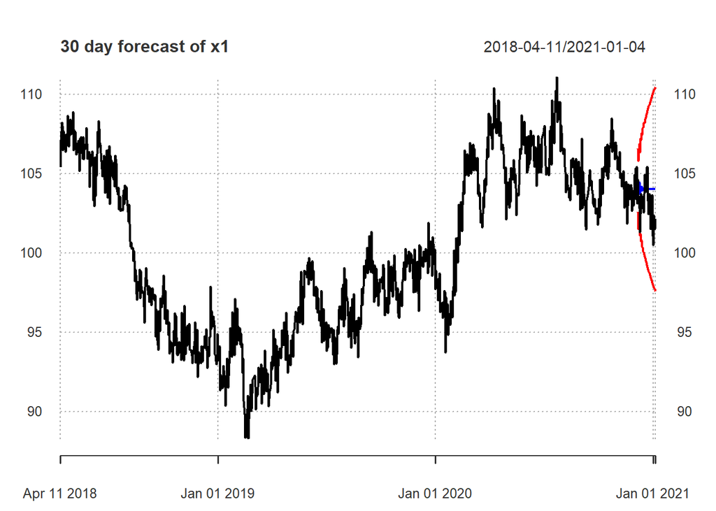

```r
plot(Data_x1_combined [, c("x1", "f_mean", "f_lower", "f_upper")],
     major.ticks = "years",
     grid.ticks.on = "years",
     grid.ticks.lty = 3,
     main = "30 day forecast of x1",
     col = c("black", "blue", "red", "red"))
```

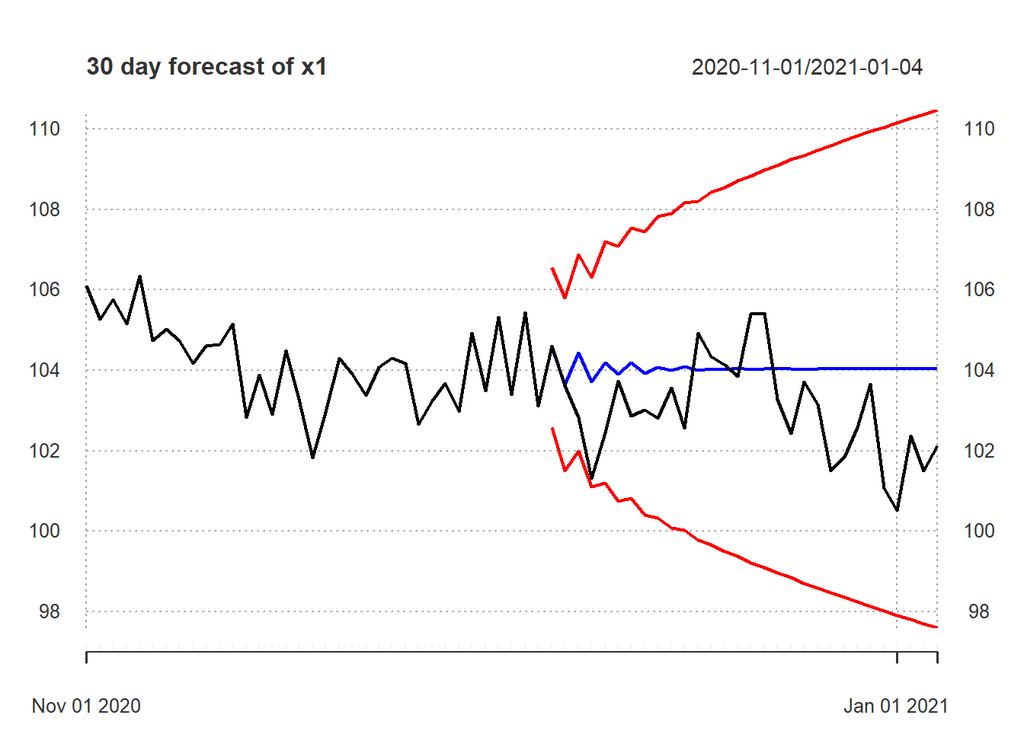

```r
plot(Data_x1_combined ["2020-11/", c("x1", "f_mean", "f_lower", "f_upper")],
     major.ticks = "years",
     grid.ticks.on = "years",
     grid.ticks.lty = 3,
     main = "30 day forecast of x1",
     col = c("black", "blue", "red", "red"))
```

Extract Data for Evaluating the Forecast:

```r
Data_x1_Eva <- tail(Data_x1_combined, 30)
Data_x1_Eva
```

```
##                  x1   f_mean   f_lower  f_upper
## 2020-12-06 104.6044 104.5678 102.57601 106.5596
## 2020-12-07 103.6145 103.6466 101.49883 105.7944
## 2020-12-08 102.8175 104.4368 101.99142 106.8822
## 2020-12-09 101.3033 103.7109 101.10645 106.3153
## 2020-12-10 102.4395 104.1953 101.19974 107.1909
## 2020-12-11 103.7279 103.9095 100.73484 107.0842
## 2020-12-12 102.8575 104.1790 100.81371 107.5443
## 2020-12-13 103.0086 103.9187 100.39564 107.4417
## 2020-12-14 102.8093 104.0779 100.32971 107.8260
## 2020-12-15 103.5626 103.9930 100.07959 107.9065
## 2020-12-16 102.5536 104.0867 100.01662 108.1568
## 2020-12-17 104.9300 103.9915  99.77576 108.2073
## 2020-12-18 104.3301 104.0425  99.65953 108.4255
## 2020-12-19 104.1219 104.0192  99.48927 108.5491
## 2020-12-20 103.8526 104.0527  99.38456 108.7209
## 2020-12-21 105.4009 104.0172  99.21605 108.8184
## 2020-12-22 105.4246 104.0327  99.09200 108.9735
## 2020-12-23 103.2777 104.0273  98.95505 109.0995
## 2020-12-24 102.4349 104.0398  98.84219 109.2374
## 2020-12-25 103.7180 104.0263  98.70667 109.3459
## 2020-12-26 103.1486 104.0305  98.58755 109.4735
## 2020-12-27 101.4948 104.0298  98.46733 109.5922
## 2020-12-28 101.8467 104.0347  98.35688 109.7125
## 2020-12-29 102.5797 104.0294  98.23877 109.8201
## 2020-12-30 103.6637 104.0303  98.12723 109.9334
## 2020-12-31 101.0638 104.0305  98.01739 110.0437
## 2021-01-01 100.5104 104.0326  97.91216 110.1530
## 2021-01-02 102.3766 104.0305  97.80481 110.2562
## 2021-01-03 101.5015 104.0305  97.70053 110.3605
## 2021-01-04 102.1252 104.0308  97.59824 110.4633
```

```r
Data_x1_Eva$mae   <-  abs(Data_x1_Eva$x1 - Data_x1_Eva$f_mean)
Data_x1_Eva$mse   <-  (Data_x1_Eva$x1 - Data_x1_Eva$f_mean) ^ 2
Data_x1_Eva$mape  <-  abs((Data_x1_Eva$x1 - Data_x1_Eva$f_mean)/Data_x1_Eva$x1)
Data_x1_Eva$amape <-  abs((Data_x1_Eva$x1 - Data_x1_Eva$f_mean)/(Data_x1_Eva$x1 + Data_x1_Eva$f_mean))
Data_x1_Eva
```

```
##                  x1   f_mean   f_lower  f_upper        mae          mse
## 2020-12-06 104.6044 104.5678 102.57601 106.5596 0.03660466  0.001339901
## 2020-12-07 103.6145 103.6466 101.49883 105.7944 0.03214078  0.001033030
## 2020-12-08 102.8175 104.4368 101.99142 106.8822 1.61928051  2.622069373
## 2020-12-09 101.3033 103.7109 101.10645 106.3153 2.40761193  5.796595205
## 2020-12-10 102.4395 104.1953 101.19974 107.1909 1.75578459  3.082779544
## 2020-12-11 103.7279 103.9095 100.73484 107.0842 0.18163929  0.032992831
## 2020-12-12 102.8575 104.1790 100.81371 107.5443 1.32152181  1.746419902
## 2020-12-13 103.0086 103.9187 100.39564 107.4417 0.91001295  0.828123569
## 2020-12-14 102.8093 104.0779 100.32971 107.8260 1.26855923  1.609242532
## 2020-12-15 103.5626 103.9930 100.07959 107.9065 0.43042133  0.185262518
## 2020-12-16 102.5536 104.0867 100.01662 108.1568 1.53311149  2.350430849
## 2020-12-17 104.9300 103.9915  99.77576 108.2073 0.93851010  0.880801205
## 2020-12-18 104.3301 104.0425  99.65953 108.4255 0.28757158  0.082697416
## 2020-12-19 104.1219 104.0192  99.48927 108.5491 0.10270791  0.010548914
## 2020-12-20 103.8526 104.0527  99.38456 108.7209 0.20015706  0.040062848
## 2020-12-21 105.4009 104.0172  99.21605 108.8184 1.38369455  1.914610617
## 2020-12-22 105.4246 104.0327  99.09200 108.9735 1.39185676  1.937265232
## 2020-12-23 103.2777 104.0273  98.95505 109.0995 0.74960674  0.561910257
## 2020-12-24 102.4349 104.0398  98.84219 109.2374 1.60483551  2.575497003
## 2020-12-25 103.7180 104.0263  98.70667 109.3459 0.30829309  0.095044631
## 2020-12-26 103.1486 104.0305  98.58755 109.4735 0.88191051  0.777766144
## 2020-12-27 101.4948 104.0298  98.46733 109.5922 2.53492685  6.425854112
## 2020-12-28 101.8467 104.0347  98.35688 109.7125 2.18801355  4.787403309
## 2020-12-29 102.5797 104.0294  98.23877 109.8201 1.44970001  2.101630123
## 2020-12-30 103.6637 104.0303  98.12723 109.9334 0.36666172  0.134440817
## 2020-12-31 101.0638 104.0305  98.01739 110.0437 2.96676333  8.801684647
## 2021-01-01 100.5104 104.0326  97.91216 110.1530 3.52221649 12.406008988
## 2021-01-02 102.3766 104.0305  97.80481 110.2562 1.65387995  2.735318895
## 2021-01-03 101.5015 104.0305  97.70053 110.3605 2.52903620  6.396024080
## 2021-01-04 102.1252 104.0308  97.59824 110.4633 1.90555415  3.631136608
##                    mape        amape
## 2020-12-06 0.0003499342 0.0001749977
## 2020-12-07 0.0003101958 0.0001550739
## 2020-12-08 0.0157490725 0.0078130124
## 2020-12-09 0.0237663751 0.0117436357
## 2020-12-10 0.0171397199 0.0084970415
## 2020-12-11 0.0017511137 0.0008747909
## 2020-12-12 0.0128480866 0.0063830384
## 2020-12-13 0.0088343360 0.0043977424
## 2020-12-14 0.0123389531 0.0061316475
## 2020-12-15 0.0041561456 0.0020737633
## 2020-12-16 0.0149493696 0.0074192284
## 2020-12-17 0.0089441500 0.0044921643
## 2020-12-18 0.0027563633 0.0013800836
## 2020-12-19 0.0009864198 0.0004934533
## 2020-12-20 0.0019273194 0.0009627319
## 2020-12-21 0.0131279183 0.0066073294
## 2020-12-22 0.0132023912 0.0066450610
## 2020-12-23 0.0072581686 0.0036159617
## 2020-12-24 0.0156668747 0.0077725515
## 2020-12-25 0.0029724173 0.0014840031
## 2020-12-26 0.0085499008 0.0042567530
## 2020-12-27 0.0249759214 0.0123339350
## 2020-12-28 0.0214834099 0.0106275470
## 2020-12-29 0.0141324215 0.0070166298
## 2020-12-30 0.0035370320 0.0017653939
## 2020-12-31 0.0293553610 0.0144653625
## 2021-01-01 0.0350433171 0.0172199367
## 2021-01-02 0.0161548571 0.0080127065
## 2021-01-03 0.0249162464 0.0123048282
## 2021-01-04 0.0186589942 0.0092432621
```

```r
ARIMA_x1 <- colMeans(Data_x1_Eva[, c("mae", "mse", "mape", "amape")])
apply(Data_x1_Eva[, c("mae", "mse", "mape", "amape")], 2, FUN = median)
```

```
##         mae         mse        mape       amape
## 1.352608183 1.830515260 0.012988002 0.006495184
```

#FORECAST X2

Assign forecast X2 to object oos_x2

```r
oos_x2 <- out_of_sample$x2

oos_x2
```

```
##                   x2
## 2020-12-06 101.99487
## 2020-12-07 103.34756
## 2020-12-08 103.38339
## 2020-12-09 102.65495
## 2020-12-10 103.14643
## 2020-12-11 101.29482
## 2020-12-12 102.82414
## 2020-12-13 102.60263
## 2020-12-14 102.48089
## 2020-12-15 102.83048
## 2020-12-16 103.74833
## 2020-12-17 104.77165
## 2020-12-18 102.25474
## 2020-12-19 101.73088
## 2020-12-20 102.61676
## 2020-12-21 100.11499
## 2020-12-22 100.82839
## 2020-12-23 101.55266
## 2020-12-24 101.81775
## 2020-12-25 101.75292
## 2020-12-26 100.70069
## 2020-12-27 102.97327
## 2020-12-28 103.15157
## 2020-12-29 102.18853
## 2020-12-30  99.62443
## 2020-12-31 104.57416
## 2021-01-01 102.09902
## 2021-01-02 100.91690
## 2021-01-03  98.09291
## 2021-01-04 102.21843
```

```r
tail(Data, 12)
```

```
##                  x1       x2       x3       x4       x5       x6       x7
## 2020-11-24 104.3013 104.3355 140.7577 119.5638 114.1140 154.3604 153.2460
## 2020-11-25 104.1657 105.1016 141.4567 123.3867 113.5237 154.0791 153.7337
## 2020-11-26 102.6537 104.9208 140.7758 124.4254 112.9245 156.0804 154.2043
## 2020-11-27 103.2396 105.7320 140.4508 124.7773 114.9400 157.1855 155.4884
## 2020-11-28 103.6736 102.9653 141.7815 123.5558 115.1752 155.7699 152.7099
## 2020-11-29 102.9761 104.5524 140.6848 124.9638 113.3780 155.9102 157.3308
## 2020-11-30 104.9255 102.0271 140.3751 123.5249 114.2484 154.4416 154.2609
## 2020-12-01 103.4802 102.7281 139.8656 124.8164 115.4927 153.0521 156.7857
## 2020-12-02 105.3159 103.5042 141.6949 125.9501 113.2420 154.6303 154.1157
## 2020-12-03 103.3953 102.4242 142.7535 126.2372 112.9752 156.1399 154.1009
## 2020-12-04 105.4361 102.8317 141.2816 125.7234 115.3071 156.6897 154.6461
## 2020-12-05 103.1150 101.9375 141.2156 125.2633 115.3152 156.7915 155.2692
##                  x8       x9      x10        dx1        dx2
## 2020-11-24 187.7767 45.31686 160.3198  0.2285039 -0.1819140
## 2020-11-25 188.6371 47.13610 158.2888 -0.1355977  0.7660739
## 2020-11-26 189.0998 46.20568 159.0346 -1.5119562 -0.1807765
## 2020-11-27 188.8698 45.66828 158.1373  0.5859083  0.8111557
## 2020-11-28 187.4831 44.49097 158.9628  0.4339784 -2.7666582
## 2020-11-29 189.1835 43.55099 158.6368 -0.6975379  1.5870744
## 2020-11-30 190.5172 42.14053 158.4194  1.9494719 -2.5252541
## 2020-12-01 187.9916 41.04858 158.8728 -1.4453358  0.7009970
## 2020-12-02 189.1746 41.14571 157.2235  1.8357427  0.7760933
## 2020-12-03 191.1886 41.65493 160.8470 -1.9206885 -1.0800434
## 2020-12-04 190.2398 42.99143 159.4651  2.0407973  0.4074824
## 2020-12-05 188.6125 41.27213 158.3798 -2.3210339 -0.8941768
```

```r
forecasts_x2 <- forecast(arima510_x2, # model for prediction
                         h = 30) # how many periods outside the sample

forecasts_x2
```

```
##      Point Forecast     Lo 80    Hi 80     Lo 95    Hi 95
##  971       102.8393 101.51445 104.1641 100.81312 104.8654
##  972       102.2730 100.86707 103.6789 100.12284 104.4231
##  973       102.4972 100.94235 104.0521 100.11924 104.8753
##  974       102.2039 100.54844 103.8593  99.67212 104.7356
##  975       102.5257 100.57887 104.4725  99.54830 105.5031
##  976       102.3373 100.27407 104.4006  99.18185 105.4928
##  977       102.4015 100.21039 104.5925  99.05050 105.7524
##  978       102.3190 100.01093 104.6271  98.78909 105.8490
##  979       102.4248  99.95891 104.8908  98.65353 106.1961
##  980       102.3631  99.78713 104.9392  98.42346 106.3028
##  981       102.3794  99.69382 105.0650  98.27216 106.4866
##  982       102.3575  99.56504 105.1500  98.08679 106.6283
##  983       102.3919  99.48463 105.2992  97.94560 106.8382
##  984       102.3713  99.36505 105.3775  97.77365 106.9689
```

[output cut: 16 more lines]

Extract the forecast points

```r
forecasts_x2$mean
```

```
## Time Series:
## Start = 971
## End = 1000
## Frequency = 1
##  [1] 102.8393 102.2730 102.4972 102.2039 102.5257 102.3373 102.4015 102.3190
##  [9] 102.4248 102.3631 102.3794 102.3575 102.3919 102.3713 102.3750 102.3697
## [17] 102.3808 102.3738 102.3745 102.3734 102.3770 102.3745 102.3747 102.3745
## [25] 102.3757 102.3748 102.3748 102.3748 102.3752 102.3749
```

```r
class(forecasts_x2$mean)
```

```
## [1] "ts"
```

It is a ts object, not xts! However, the xts objects are more convenient and modern. In terms of plotting the real data and forecast data to compare.

```r
forecasts_x2$lower
```

```
## Time Series:
## Start = 971
## End = 1000
## Frequency = 1
##            80%       95%
##  971 101.51445 100.81312
##  972 100.86707 100.12284
##  973 100.94235 100.11924
##  974 100.54844  99.67212
##  975 100.57887  99.54830
##  976 100.27407  99.18185
##  977 100.21039  99.05050
##  978 100.01093  98.78909
##  979  99.95891  98.65353
##  980  99.78713  98.42346
```

[output cut: 20 more lines]

```r
forecasts_x2$upper
```

```
## Time Series:
## Start = 971
## End = 1000
## Frequency = 1
##           80%      95%
##  971 104.1641 104.8654
##  972 103.6789 104.4231
##  973 104.0521 104.8753
##  974 103.8593 104.7356
##  975 104.4725 105.5031
##  976 104.4006 105.4928
##  977 104.5925 105.7524
##  978 104.6271 105.8490
##  979 104.8908 106.1961
##  980 104.9392 106.3028
```

[output cut: 20 more lines]

Create xts object: (We use the second column (95% confidence interval))

```r
forecasts_x2_data <- data.frame(f_mean = as.numeric(forecasts_x2$mean),
                                f_lower = as.numeric(forecasts_x2$lower[, 2]),
                                f_upper = as.numeric(forecasts_x2$upper[, 2]))
```

```r
head(forecasts_x2_data,30)
```

```
##      f_mean   f_lower  f_upper
## 1  102.8393 100.81312 104.8654
## 2  102.2730 100.12284 104.4231
## 3  102.4972 100.11924 104.8753
## 4  102.2039  99.67212 104.7356
## 5  102.5257  99.54830 105.5031
## 6  102.3373  99.18185 105.4928
## 7  102.4015  99.05050 105.7524
## 8  102.3190  98.78909 105.8490
## 9  102.4248  98.65353 106.1961
## 10 102.3631  98.42346 106.3028
## 11 102.3794  98.27216 106.4866
## 12 102.3575  98.08679 106.6283
## 13 102.3919  97.94560 106.8382
## 14 102.3713  97.77365 106.9689
```

[output cut: 16 more lines]

```r
Data_x2 <- rbind(Data[, "x2"], oos_x2)
tail(Data_x2, n = 40)
```

```
##                   x2
## 2020-11-26 104.92083
## 2020-11-27 105.73198
## 2020-11-28 102.96533
## 2020-11-29 104.55240
## 2020-11-30 102.02715
## 2020-12-01 102.72814
## 2020-12-02 103.50424
## 2020-12-03 102.42419
## 2020-12-04 102.83168
## 2020-12-05 101.93750
## 2020-12-06 101.99487
## 2020-12-07 103.34756
## 2020-12-08 103.38339
## 2020-12-09 102.65495
## 2020-12-10 103.14643
## 2020-12-11 101.29482
## 2020-12-12 102.82414
## 2020-12-13 102.60263
## 2020-12-14 102.48089
## 2020-12-15 102.83048
## 2020-12-16 103.74833
## 2020-12-17 104.77165
## 2020-12-18 102.25474
## 2020-12-19 101.73088
## 2020-12-20 102.61676
## 2020-12-21 100.11499
## 2020-12-22 100.82839
## 2020-12-23 101.55266
## 2020-12-24 101.81775
## 2020-12-25 101.75292
## 2020-12-26 100.70069
## 2020-12-27 102.97327
## 2020-12-28 103.15157
## 2020-12-29 102.18853
## 2020-12-30  99.62443
## 2020-12-31 104.57416
## 2021-01-01 102.09902
## 2021-01-02 100.91690
## 2021-01-03  98.09291
## 2021-01-04 102.21843
```

Turn Forecast with Index into Forecast with Date

```r
forecasts_x2_xts <- xts(forecasts_x2_data,
                        order.by = index(oos_x2))
forecasts_x2_xts
```

```
##              f_mean   f_lower  f_upper
## 2020-12-06 102.8393 100.81312 104.8654
## 2020-12-07 102.2730 100.12284 104.4231
## 2020-12-08 102.4972 100.11924 104.8753
## 2020-12-09 102.2039  99.67212 104.7356
## 2020-12-10 102.5257  99.54830 105.5031
## 2020-12-11 102.3373  99.18185 105.4928
## 2020-12-12 102.4015  99.05050 105.7524
## 2020-12-13 102.3190  98.78909 105.8490
## 2020-12-14 102.4248  98.65353 106.1961
## 2020-12-15 102.3631  98.42346 106.3028
## 2020-12-16 102.3794  98.27216 106.4866
## 2020-12-17 102.3575  98.08679 106.6283
## 2020-12-18 102.3919  97.94560 106.8382
## 2020-12-19 102.3713  97.77365 106.9689
## 2020-12-20 102.3750  97.62935 107.1207
## 2020-12-21 102.3697  97.47832 107.2611
## 2020-12-22 102.3808  97.34325 107.4184
## 2020-12-23 102.3738  97.19967 107.5478
## 2020-12-24 102.3745  97.06694 107.6821
## 2020-12-25 102.3734  96.93455 107.8123
## 2020-12-26 102.3770  96.80872 107.9453
## 2020-12-27 102.3745  96.68159 108.0675
## 2020-12-28 102.3747  96.55953 108.1898
## 2020-12-29 102.3745  96.43927 108.3098
## 2020-12-30 102.3757  96.32238 108.4290
## 2020-12-31 102.3748  96.20631 108.5433
## 2021-01-01 102.3748  96.09317 108.6564
## 2021-01-02 102.3748  95.98188 108.7678
## 2021-01-03 102.3752  95.87274 108.8777
## 2021-01-04 102.3749  95.76495 108.9848
```

Merge it together with the original data

```r
Data_x2_combined <- merge(Data_x2, forecasts_x2_xts)
head(Data_x2_combined)
```

```
##                  x2 f_mean f_lower f_upper
## 2018-04-11 109.6174     NA      NA      NA
## 2018-04-12 109.9211     NA      NA      NA
## 2018-04-13 109.4070     NA      NA      NA
## 2018-04-14 108.3335     NA      NA      NA
## 2018-04-15 108.4117     NA      NA      NA
## 2018-04-16 108.6879     NA      NA      NA
```

```r
tail(Data_x2_combined,40)
```

```
##                   x2   f_mean   f_lower  f_upper
## 2020-11-26 104.92083       NA        NA       NA
## 2020-11-27 105.73198       NA        NA       NA
## 2020-11-28 102.96533       NA        NA       NA
## 2020-11-29 104.55240       NA        NA       NA
## 2020-11-30 102.02715       NA        NA       NA
## 2020-12-01 102.72814       NA        NA       NA
## 2020-12-02 103.50424       NA        NA       NA
## 2020-12-03 102.42419       NA        NA       NA
## 2020-12-04 102.83168       NA        NA       NA
## 2020-12-05 101.93750       NA        NA       NA
## 2020-12-06 101.99487 102.8393 100.81312 104.8654
## 2020-12-07 103.34756 102.2730 100.12284 104.4231
## 2020-12-08 103.38339 102.4972 100.11924 104.8753
## 2020-12-09 102.65495 102.2039  99.67212 104.7356
## 2020-12-10 103.14643 102.5257  99.54830 105.5031
## 2020-12-11 101.29482 102.3373  99.18185 105.4928
## 2020-12-12 102.82414 102.4015  99.05050 105.7524
## 2020-12-13 102.60263 102.3190  98.78909 105.8490
## 2020-12-14 102.48089 102.4248  98.65353 106.1961
## 2020-12-15 102.83048 102.3631  98.42346 106.3028
## 2020-12-16 103.74833 102.3794  98.27216 106.4866
## 2020-12-17 104.77165 102.3575  98.08679 106.6283
## 2020-12-18 102.25474 102.3919  97.94560 106.8382
## 2020-12-19 101.73088 102.3713  97.77365 106.9689
## 2020-12-20 102.61676 102.3750  97.62935 107.1207
## 2020-12-21 100.11499 102.3697  97.47832 107.2611
## 2020-12-22 100.82839 102.3808  97.34325 107.4184
## 2020-12-23 101.55266 102.3738  97.19967 107.5478
## 2020-12-24 101.81775 102.3745  97.06694 107.6821
## 2020-12-25 101.75292 102.3734  96.93455 107.8123
## 2020-12-26 100.70069 102.3770  96.80872 107.9453
## 2020-12-27 102.97327 102.3745  96.68159 108.0675
## 2020-12-28 103.15157 102.3747  96.55953 108.1898
## 2020-12-29 102.18853 102.3745  96.43927 108.3098
## 2020-12-30  99.62443 102.3757  96.32238 108.4290
## 2020-12-31 104.57416 102.3748  96.20631 108.5433
## 2021-01-01 102.09902 102.3748  96.09317 108.6564
## 2021-01-02 100.91690 102.3748  95.98188 108.7678
## 2021-01-03  98.09291 102.3752  95.87274 108.8777
## 2021-01-04 102.21843 102.3749  95.76495 108.9848
```

Plot Chart

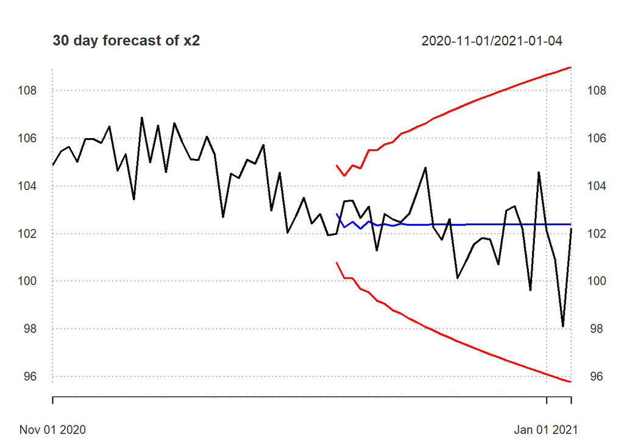

```r
plot(Data_x2_combined ["2020-11/", c("x2", "f_mean", "f_lower", "f_upper")],
     major.ticks = "years",
     grid.ticks.on = "years",
     grid.ticks.lty = 3,
     main = "30 day forecast of x2",
     col = c("black", "blue", "red", "red"))
```

Extract Data for Evaluating the Forecast:

```r
Data_x2_Eva <- tail(Data_x2_combined, 30)
Data_x2_Eva
```

```
##                   x2   f_mean   f_lower  f_upper
## 2020-12-06 101.99487 102.8393 100.81312 104.8654
## 2020-12-07 103.34756 102.2730 100.12284 104.4231
## 2020-12-08 103.38339 102.4972 100.11924 104.8753
## 2020-12-09 102.65495 102.2039  99.67212 104.7356
## 2020-12-10 103.14643 102.5257  99.54830 105.5031
## 2020-12-11 101.29482 102.3373  99.18185 105.4928
## 2020-12-12 102.82414 102.4015  99.05050 105.7524
## 2020-12-13 102.60263 102.3190  98.78909 105.8490
## 2020-12-14 102.48089 102.4248  98.65353 106.1961
## 2020-12-15 102.83048 102.3631  98.42346 106.3028
## 2020-12-16 103.74833 102.3794  98.27216 106.4866
## 2020-12-17 104.77165 102.3575  98.08679 106.6283
## 2020-12-18 102.25474 102.3919  97.94560 106.8382
## 2020-12-19 101.73088 102.3713  97.77365 106.9689
## 2020-12-20 102.61676 102.3750  97.62935 107.1207
## 2020-12-21 100.11499 102.3697  97.47832 107.2611
## 2020-12-22 100.82839 102.3808  97.34325 107.4184
## 2020-12-23 101.55266 102.3738  97.19967 107.5478
## 2020-12-24 101.81775 102.3745  97.06694 107.6821
## 2020-12-25 101.75292 102.3734  96.93455 107.8123
## 2020-12-26 100.70069 102.3770  96.80872 107.9453
## 2020-12-27 102.97327 102.3745  96.68159 108.0675
## 2020-12-28 103.15157 102.3747  96.55953 108.1898
## 2020-12-29 102.18853 102.3745  96.43927 108.3098
## 2020-12-30  99.62443 102.3757  96.32238 108.4290
## 2020-12-31 104.57416 102.3748  96.20631 108.5433
## 2021-01-01 102.09902 102.3748  96.09317 108.6564
## 2021-01-02 100.91690 102.3748  95.98188 108.7678
## 2021-01-03  98.09291 102.3752  95.87274 108.8777
## 2021-01-04 102.21843 102.3749  95.76495 108.9848
```

```r
Data_x2_Eva$mae   <-  abs(Data_x2_Eva$x2 - Data_x2_Eva$f_mean)
Data_x2_Eva$mse   <-  (Data_x2_Eva$x2 - Data_x2_Eva$f_mean) ^ 2
Data_x2_Eva$mape  <-  abs((Data_x2_Eva$x2 - Data_x2_Eva$f_mean)/Data_x2_Eva$x2)
Data_x2_Eva$amape <-  abs((Data_x2_Eva$x2 - Data_x2_Eva$f_mean)/(Data_x2_Eva$x2 + Data_x2_Eva$f_mean))
Data_x2_Eva
```

```
##                   x2   f_mean   f_lower  f_upper        mae          mse
## 2020-12-06 101.99487 102.8393 100.81312 104.8654 0.84440428  0.713018594
## 2020-12-07 103.34756 102.2730 100.12284 104.4231 1.07459191  1.154747779
## 2020-12-08 103.38339 102.4972 100.11924 104.8753 0.88613819  0.785240898
## 2020-12-09 102.65495 102.2039  99.67212 104.7356 0.45108762  0.203480039
## 2020-12-10 103.14643 102.5257  99.54830 105.5031 0.62075767  0.385340080
## 2020-12-11 101.29482 102.3373  99.18185 105.4928 1.04250402  1.086814624
## 2020-12-12 102.82414 102.4015  99.05050 105.7524 0.42267568  0.178654727
## 2020-12-13 102.60263 102.3190  98.78909 105.8490 0.28359718  0.080427363
## 2020-12-14 102.48089 102.4248  98.65353 106.1961 0.05605681  0.003142366
## 2020-12-15 102.83048 102.3631  98.42346 106.3028 0.46733257  0.218399735
## 2020-12-16 103.74833 102.3794  98.27216 106.4866 1.36894247  1.874003492
## 2020-12-17 104.77165 102.3575  98.08679 106.6283 2.41410282  5.827892427
## 2020-12-18 102.25474 102.3919  97.94560 106.8382 0.13717593  0.018817235
## 2020-12-19 101.73088 102.3713  97.77365 106.9689 0.64039817  0.410109819
## 2020-12-20 102.61676 102.3750  97.62935 107.1207 0.24173247  0.058434587
## 2020-12-21 100.11499 102.3697  97.47832 107.2611 2.25470204  5.083681304
## 2020-12-22 100.82839 102.3808  97.34325 107.4184 1.55243228  2.410045994
## 2020-12-23 101.55266 102.3738  97.19967 107.5478 0.82109757  0.674201215
## 2020-12-24 101.81775 102.3745  97.06694 107.6821 0.55676647  0.309988905
## 2020-12-25 101.75292 102.3734  96.93455 107.8123 0.62050327  0.385024305
## 2020-12-26 100.70069 102.3770  96.80872 107.9453 1.67632087  2.810051675
## 2020-12-27 102.97327 102.3745  96.68159 108.0675 0.59873445  0.358482936
## 2020-12-28 103.15157 102.3747  96.55953 108.1898 0.77691565  0.603597926
## 2020-12-29 102.18853 102.3745  96.43927 108.3098 0.18600274  0.034597021
## 2020-12-30  99.62443 102.3757  96.32238 108.4290 2.75124974  7.569375138
## 2020-12-31 104.57416 102.3748  96.20631 108.5433 2.19935975  4.837183304
## 2021-01-01 102.09902 102.3748  96.09317 108.6564 0.27578302  0.076056276
## 2021-01-02 100.91690 102.3748  95.98188 108.7678 1.45794267  2.125596825
## 2021-01-03  98.09291 102.3752  95.87274 108.8777 4.28229936 18.338087848
## 2021-01-04 102.21843 102.3749  95.76495 108.9848 0.15646094  0.024480026
##                    mape        amape
## 2020-12-06 0.0082788895 0.0041223804
## 2020-12-07 0.0103978453 0.0052260927
## 2020-12-08 0.0085713790 0.0043041357
## 2020-12-09 0.0043942120 0.0022019439
## 2020-12-10 0.0060182175 0.0030181908
## 2020-12-11 0.0102917805 0.0051195456
## 2020-12-12 0.0041106659 0.0020595661
## 2020-12-13 0.0027640341 0.0013839297
## 2020-12-14 0.0005469977 0.0002735737
## 2020-12-15 0.0045446891 0.0022775199
## 2020-12-16 0.0131948382 0.0066412341
## 2020-12-17 0.0230415664 0.0116550586
## 2020-12-18 0.0013415117 0.0006703062
## 2020-12-19 0.0062950225 0.0031376355
## 2020-12-20 0.0023556821 0.0011792300
## 2020-12-21 0.0225211227 0.0111351731
## 2020-12-22 0.0153967770 0.0076395761
## 2020-12-23 0.0080854363 0.0040264404
## 2020-12-24 0.0054682654 0.0027266776
## 2020-12-25 0.0060981374 0.0030398001
## 2020-12-26 0.0166465680 0.0082545788
## 2020-12-27 0.0058144646 0.0029157089
## 2020-12-28 0.0075317870 0.0037801291
## 2020-12-29 0.0018201921 0.0009092685
## 2020-12-30 0.0276162157 0.0136200409
## 2020-12-31 0.0210315797 0.0106275469
## 2021-01-01 0.0027011329 0.0013487449
## 2021-01-02 0.0144469619 0.0071716765
## 2021-01-03 0.0436555433 0.0213614978
## 2021-01-04 0.0015306529 0.0007647412
```

```r
ARIMA_x2 <- colMeans(Data_x2_Eva[, c("mae", "mse", "mape", "amape")])
apply(Data_x2_Eva[, c("mae", "mse", "mape", "amape")], 2, FUN = median)
```

```
##         mae         mse        mape       amape
## 0.708656911 0.506853873 0.006913405 0.003458882
```

#5. VECM Model and Analysis

##5.1. Johansen cointegration test

We will assume the K=5 lag structure:

```r
johan.test.trace <-
ca.jo(Data[,1:2], # data
        ecdet = "const", # "none" for no intercept in cointegrating equation,
        # "const" for constant term in cointegrating equation and
        # "trend" for trend variable in cointegrating equation
        type = "trace",  # type of the test: trace or eigen
        K = 5           # lag order of the series (levels) in the VAR
)

summary(johan.test.trace)
```

```
##
## ######################
## # Johansen-Procedure #
## ######################
##
## Test type: trace statistic , without linear trend and constant in cointegration
##
## Eigenvalues (lambda):
## [1]  6.383817e-02  4.117299e-03 -4.742219e-19
##
## Values of teststatistic and critical values of test:
##
##           test 10pct  5pct  1pct
## r <= 1 |  3.98  7.52  9.24 12.97
## r = 0  | 67.64 17.85 19.96 24.60
##
## Eigenvectors, normalised to first column:
## (These are the cointegration relations)
##
##                x1.l5       x2.l5   constant
## x1.l5      1.0000000    1.000000   1.000000
## x2.l5     -0.7787017    1.022169  -1.640237
## constant -23.5069186 -199.572540 124.644976
##
## Weights W:
## (This is the loading matrix)
##
##            x1.l5         x2.l5      constant
## x1.d 0.001831292 -0.0055472163 -1.109976e-17
## x2.d 0.136407934  0.0001014469  7.786525e-17
```

```r
cbind(summary(johan.test.trace)@teststat,

summary(johan.test.trace)@cval)
```

```
##                    10pct  5pct  1pct
## r <= 1 |  3.981396  7.52  9.24 12.97
## r = 0  | 67.639478 17.85 19.96 24.60
```

Test Statistic < Critical Value: CANNOT reject the null Test Statistic > Critical Value: reject the null First we start with r=0, (no cointegrating vector): t-test statistic > Critical value: we reject the null hypothesis about NO cointerating vector. Next, we test the hypothesis of r=1: Test Statistic < Critical Value: we CANNOT reject the null about 1 cointegrating vector. The model has ONLY 1 cointegrating vector.

```r
summary(johan.test.trace)@V
```

```
##                x1.l5       x2.l5   constant
## x1.l5      1.0000000    1.000000   1.000000
## x2.l5     -0.7787017    1.022169  -1.640237
## constant -23.5069186 -199.572540 124.644976
```

Weights W:

```r
summary(johan.test.trace)@W
```

```
##            x1.l5         x2.l5      constant
## x1.d 0.001831292 -0.0055472163 -1.109976e-17
## x2.d 0.136407934  0.0001014469  7.786525e-17
```

##Check for another type of test: for Eigen:

```r
johan.test.eigen <-
  ca.jo(Data[,1:2], # data
        ecdet = "const", # "none" for no intercept in cointegrating equation,
        # "const" for constant term in cointegrating equation and
        # "trend" for trend variable in cointegrating equation
        type = "eigen",  # type of the test: trace or eigen
        K = 5           # lag order of the series (levels) in the VAR
)
summary(johan.test.eigen)
```

```
##
## ######################
## # Johansen-Procedure #
## ######################
##
## Test type: maximal eigenvalue statistic (lambda max) , without linear trend and constant in cointegration
##
## Eigenvalues (lambda):
## [1]  6.383817e-02  4.117299e-03 -4.742219e-19
##
## Values of teststatistic and critical values of test:
##
##           test 10pct  5pct  1pct
## r <= 1 |  3.98  7.52  9.24 12.97
## r = 0  | 63.66 13.75 15.67 20.20
##
## Eigenvectors, normalised to first column:
## (These are the cointegration relations)
##
##                x1.l5       x2.l5   constant
## x1.l5      1.0000000    1.000000   1.000000
## x2.l5     -0.7787017    1.022169  -1.640237
## constant -23.5069186 -199.572540 124.644976
##
## Weights W:
## (This is the loading matrix)
##
##            x1.l5         x2.l5      constant
## x1.d 0.001831292 -0.0055472163 -1.109976e-17
## x2.d 0.136407934  0.0001014469  7.786525e-17
```

The conclusion stays the same: There is only one cointegrating vector.

##5.2. The VECM model

Define the specification of the VECM model, with cointegrating vector from either trace or eigen test from Johansen test.

```r
Data.vec5 <- cajorls(johan.test.eigen, # defined specification
                        r = 1) # number of cointegrating vectors

summary(Data.vec5)
```

```
##      Length Class  Mode
## rlm  12     mlm    list
## beta  3     -none- numeric
```

Summary results:

```r
summary(Data.vec5$rlm)
```

```
## Response x1.d :
##
## Call:
## lm(formula = x1.d ~ ect1 + x1.dl1 + x2.dl1 + x1.dl2 + x2.dl2 +
##     x1.dl3 + x2.dl3 + x1.dl4 + x2.dl4 - 1, data = data.mat)
##
## Residuals:
##     Min      1Q  Median      3Q     Max
## -3.7697 -0.6577 -0.0178  0.6824  3.1430
##
## Coefficients:
##         Estimate Std. Error t value Pr(>|t|)
## ect1    0.001831   0.017406   0.105 0.916232
## x1.dl1 -0.581860   0.032074 -18.141  < 2e-16 ***
## x2.dl1  0.013801   0.033052   0.418 0.676366
## x1.dl2 -0.186391   0.036885  -5.053  5.2e-07 ***
## x2.dl2  0.011708   0.039978   0.293 0.769696
## x1.dl3 -0.143567   0.037405  -3.838 0.000132 ***
## x2.dl3  0.014572   0.040802   0.357 0.721068
## x1.dl4  0.131532   0.033796   3.892 0.000106 ***
## x2.dl4 -0.035467   0.036140  -0.981 0.326661
## ---
## Signif. codes:  0 '***' 0.001 '**' 0.01 '*' 0.05 '.' 0.1 ' ' 1
##
## Residual standard error: 1.022 on 956 degrees of freedom
## Multiple R-squared:  0.3543, Adjusted R-squared:  0.3482
## F-statistic: 58.28 on 9 and 956 DF,  p-value: < 2.2e-16
##
##
## Response x2.d :
##
## Call:
## lm(formula = x2.d ~ ect1 + x1.dl1 + x2.dl1 + x1.dl2 + x2.dl2 +
##     x1.dl3 + x2.dl3 + x1.dl4 + x2.dl4 - 1, data = data.mat)
##
## Residuals:
##     Min      1Q  Median      3Q     Max
## -2.7612 -0.6454 -0.0207  0.6840  2.9438
##
## Coefficients:
##        Estimate Std. Error t value Pr(>|t|)
## ect1    0.13641    0.01690   8.073 2.06e-15 ***
## x1.dl1  0.03566    0.03114   1.145    0.252
## x2.dl1 -0.71712    0.03209 -22.349  < 2e-16 ***
## x1.dl2  0.19574    0.03581   5.466 5.86e-08 ***
## x2.dl2 -0.42030    0.03881 -10.830  < 2e-16 ***
## x1.dl3  0.20875    0.03631   5.749 1.21e-08 ***
## x2.dl3 -0.33381    0.03961  -8.428  < 2e-16 ***
## x1.dl4  0.13824    0.03281   4.214 2.75e-05 ***
## x2.dl4  0.01372    0.03508   0.391    0.696
## ---
## Signif. codes:  0 '***' 0.001 '**' 0.01 '*' 0.05 '.' 0.1 ' ' 1
##
## Residual standard error: 0.9925 on 956 degrees of freedom
## Multiple R-squared:  0.4467, Adjusted R-squared:  0.4414
## F-statistic: 85.74 on 9 and 956 DF,  p-value: < 2.2e-16
```

extract the cointegrating vector:

```r
Data.vec5$beta
```

```
##                 ect1
## x1.l5      1.0000000
## x2.l5     -0.7787017
## constant -23.5069186
```

Reparametrizing the VEC model into VAR:

```r
Data.vec5.asVAR <- vec2var(johan.test.eigen, r = 1)
```

Check result:

```r
Data.vec5.asVAR
```

```
##
## Coefficient matrix of lagged endogenous variables:
##
## A1:
##         x1.l1      x2.l1
## x1 0.41814011 0.01380121
## x2 0.03566171 0.28288441
##
##
## A2:
##        x1.l2        x2.l2
## x1 0.3954690 -0.002093366
## x2 0.1600769  0.296815602
##
##
## A3:
##         x1.l3       x2.l3
## x1 0.04282369 0.002863953
## x2 0.01300962 0.086491778
##
##
## A4:
##          x1.l4       x2.l4
## x1  0.27509927 -0.05003865
## x2 -0.07050417  0.34752941
##
##
## A5:
##           x1.l5       x2.l5
## x1 -0.129700816  0.03404082
## x2 -0.001836086 -0.11994228
##
##
## Coefficient matrix of deterministic regressor(s).
##
##       constant
## x1 -0.04304804
## x2 -3.20653021
```

Calculate and plot Impulse Response Functions:

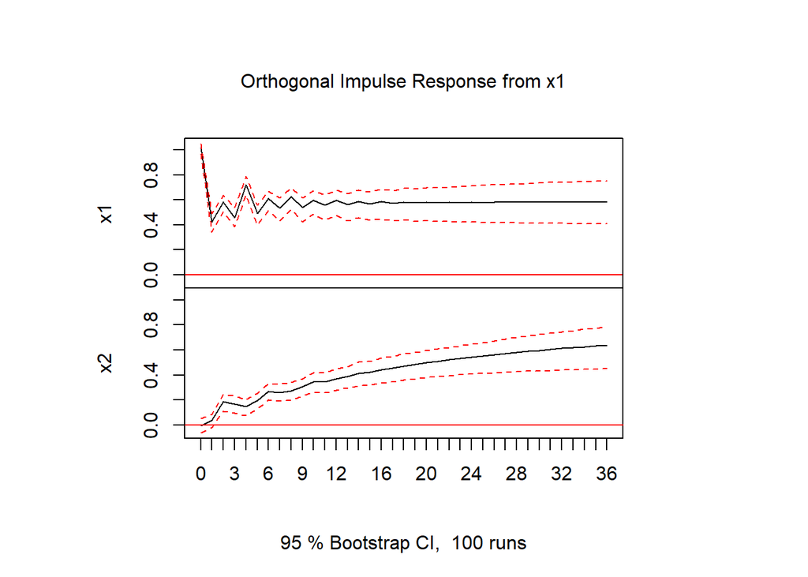

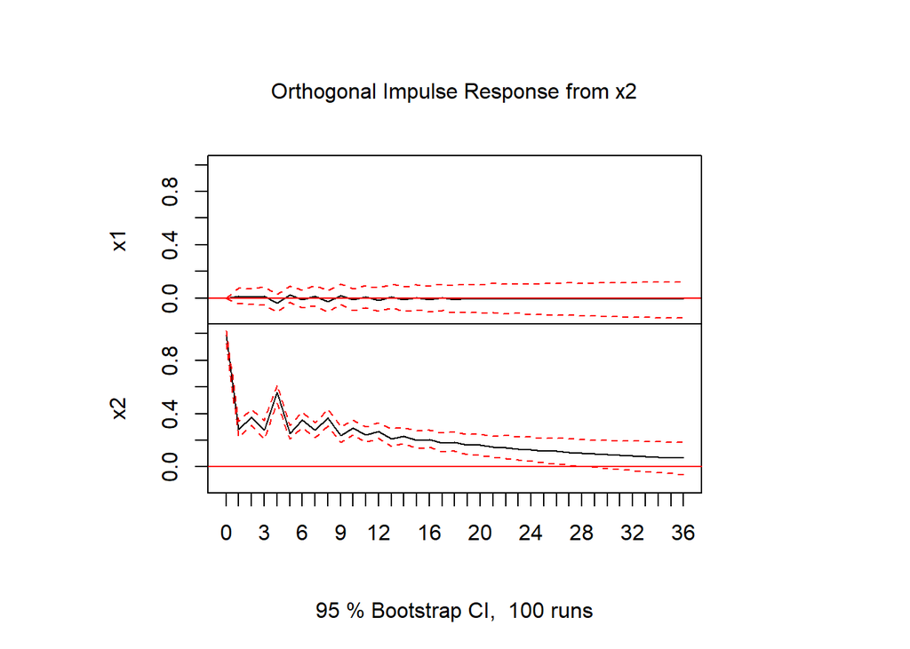

```r
plot(irf(Data.vec5.asVAR, n.ahead = 36), ask = FALSE)
```

Perform variance decomposition:

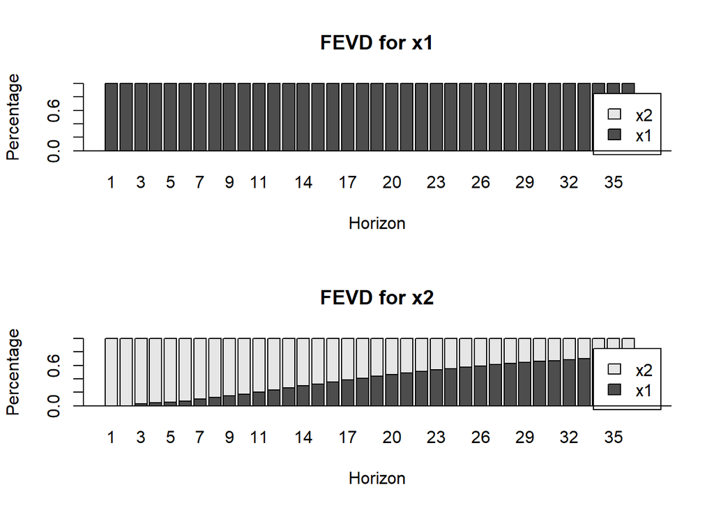

```r
plot(fevd(Data.vec5.asVAR, n.ahead = 36), ask = FALSE)
```

Check if model residuals are autocorrelated or not: Residuals can be extracted only from the VAR reparametrized model.

```r
head(residuals(Data.vec5.asVAR))
```

```
##      resids of x1 resids of x2
## [1,]   0.23578961   -0.1939324
## [2,]  -0.58882348   -0.7017903
## [3,]  -0.23862396   -0.7395508
## [4,]   0.07150805   -1.5277068
## [5,]  -0.78316066    1.0886484
## [6,]   0.90942400   -0.8624367
```

```r
serial.test(Data.vec5.asVAR)
```

```
##
##  Portmanteau Test (asymptotic)
##
## data:  Residuals of VAR object Data.vec5.asVAR
## Chi-squared = 59.807, df = 46, p-value = 0.08312
```

p-value = 0.0831 > p-critical = 5% We fail to reject about the null hypothesis about no-autocorrelation.

#-> There is no auto-correlation.

Plot ACF and PACF for the model:

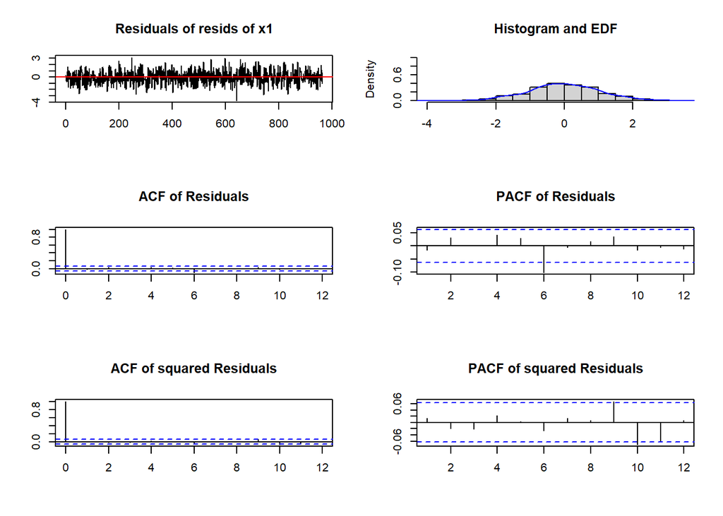

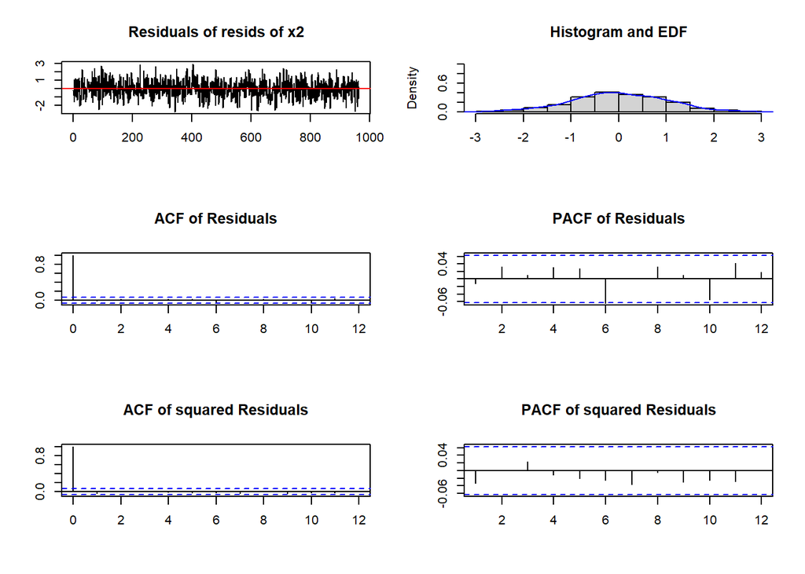

```r
plot(serial.test(Data.vec5.asVAR))
```

Checking the Nomarlity for x1 and x2 by creating Histogram:

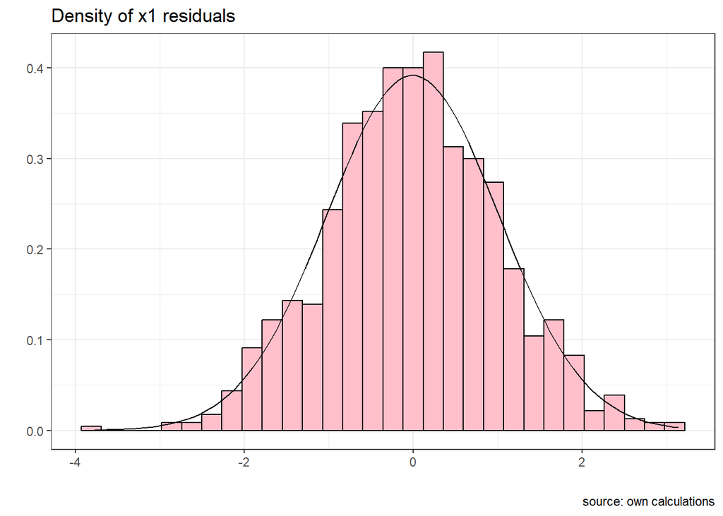

```r
Data.vec5.asVAR %>%
  residuals() %>%
  as_tibble() %>%
  ggplot(aes(`resids of x1`)) +
  geom_histogram(aes(y =..density..),
                 colour = "black",
                 fill = "pink") +
  stat_function(fun = dnorm,
                args = list(mean = mean(residuals(Data.vec5.asVAR)[, 1]),
                            sd = sd(residuals(Data.vec5.asVAR)[, 1]))) +
  theme_bw() +
  labs(
    title = "Density of x1 residuals",
    y = "", x = "",
    caption = "source: own calculations"
  )
```

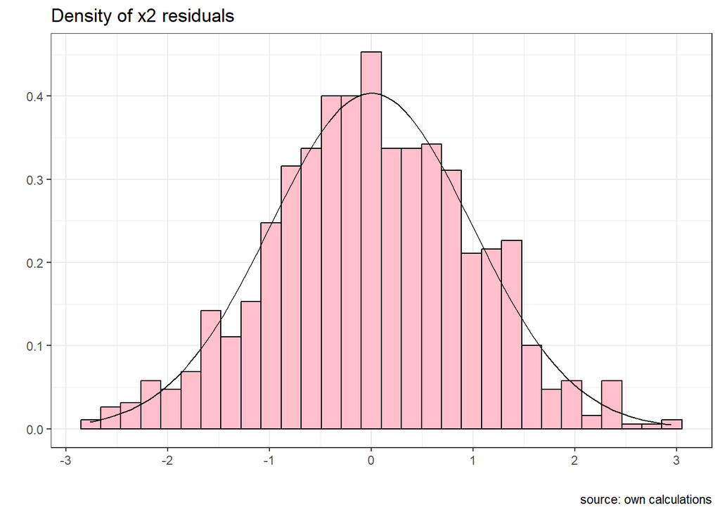

```r
Data.vec5.asVAR %>%
  residuals() %>%
  as_tibble() %>%
  ggplot(aes(`resids of x2`)) +
  geom_histogram(aes(y =..density..),
                 colour = "black",
                 fill = "pink") +
  stat_function(fun = dnorm,
                args = list(mean = mean(residuals(Data.vec5.asVAR)[, 2]),
                            sd = sd(residuals(Data.vec5.asVAR)[, 2]))) +
  theme_bw() +
  labs(
    title = "Density of x2 residuals",
    y = "", x = "",
    caption = "source: own calculations"
  )
```

We can also check it formally by using the Jarque-Bera (JB) test.

```r
normality.test(Data.vec5.asVAR)
```

```
## $JB
##
##  JB-Test (multivariate)
##
## data:  Residuals of VAR object Data.vec5.asVAR
## Chi-squared = 0.62665, df = 4, p-value = 0.9601
##
##
## $Skewness
##
##  Skewness only (multivariate)
##
## data:  Residuals of VAR object Data.vec5.asVAR
## Chi-squared = 0.20716, df = 2, p-value = 0.9016
##
##
## $Kurtosis
##
##  Kurtosis only (multivariate)
##
## data:  Residuals of VAR object Data.vec5.asVAR
## Chi-squared = 0.4195, df = 2, p-value = 0.8108
```

p-value > 0.05 => Fail to reject Ho about the normality Conclusion: the residual has a normal distribution.

##5.3 Forecasting based on the VECM

```r
Data.vec5.fore <-
  predict(
    vec2var(
      johan.test.eigen,
      r = 1),     # no of cointegrating vectors
    n.ahead = 30, # forecast horizon
    ci = 0.95)    # confidence level for intervals

summary(Data.vec5.fore)
```

```
##          Length Class   Mode
## fcst        2   -none-  list
## endog    1940   -none-  numeric
## model      12   vec2var list
## exo.fcst    0   -none-  NULL
```

VEC forecasts for x1

```r
Data.vec5.fore$fcst$x1
```

```
##           fcst     lower    upper       CI
##  [1,] 104.5515 102.55697 106.5460 1.994517
##  [2,] 103.6526 101.49059 105.8145 2.161964
##  [3,] 104.4861 102.04273 106.9295 2.443406
##  [4,] 103.7051 101.10243 106.3078 2.602707
##  [5,] 104.2788 101.31616 107.2415 2.962679
##  [6,] 103.8826 100.76626 106.9990 3.116358
##  [7,] 104.2132 100.87527 107.5512 3.337951
##  [8,] 103.9274 100.42967 107.4251 3.497731
##  [9,] 104.1469 100.43971 107.8540 3.707153
## [10,] 103.9888 100.13334 107.8442 3.855444
## [11,] 104.1162 100.08662 108.1458 4.029588
## [12,] 104.0108  99.83494 108.1867 4.175901
## [13,] 104.0931  99.75656 108.4297 4.336564
## [14,] 104.0335  99.55892 108.5082 4.474631
```

[output cut: 16 more lines]

VEC forecasts for x2

```r
Data.vec5.fore$fcst$x2
```

```
##           fcst     lower    upper       CI
##  [1,] 102.9453 101.00904 104.8815 1.936227
##  [2,] 102.3700 100.35668 104.3834 2.013352
##  [3,] 102.7276 100.55491 104.9002 2.172669
##  [4,] 102.4499 100.18770 104.7122 2.262232
##  [5,] 102.8821 100.35298 105.4112 2.529128
##  [6,] 102.5991  99.99475 105.2035 2.604379
##  [7,] 102.8270 100.08155 105.5725 2.745464
##  [8,] 102.7149  99.87151 105.5582 2.843348
##  [9,] 102.9083  99.92751 105.8892 2.980842
## [10,] 102.7926  99.71705 105.8681 3.075524
## [11,] 102.9239  99.72531 106.1225 3.198583
## [12,] 102.8787  99.57598 106.1815 3.302759
## [13,] 102.9753  99.55444 106.3961 3.420821
## [14,] 102.9355  99.40689 106.4642 3.528659
```

[output cut: 16 more lines]

Lets store it as an xts object. The correct set of dates (index) can be extracted from the out_of_sample xts data object.

```r
tail(index(out_of_sample), 30)
```

```
##  [1] "2020-12-06" "2020-12-07" "2020-12-08" "2020-12-09" "2020-12-10"
##  [6] "2020-12-11" "2020-12-12" "2020-12-13" "2020-12-14" "2020-12-15"
## [11] "2020-12-16" "2020-12-17" "2020-12-18" "2020-12-19" "2020-12-20"
## [16] "2020-12-21" "2020-12-22" "2020-12-23" "2020-12-24" "2020-12-25"
## [21] "2020-12-26" "2020-12-27" "2020-12-28" "2020-12-29" "2020-12-30"
## [26] "2020-12-31" "2021-01-01" "2021-01-02" "2021-01-03" "2021-01-04"
```

```r
x1_forecast <- xts(Data.vec5.fore$fcst$x1[,-4],
                    # we exclude the last column with CI
                    tail(index(out_of_sample), 30))
```

Correction of the variable names:

```r
names(x1_forecast) <- c("x1_fore", "x1_lower", "x1_upper")
```

Apply similarly for x2:

```r
x2_forecast <- xts(Data.vec5.fore$fcst$x2[, -4],
                    # we exclude the last column with CI
                    tail(index(out_of_sample), 30))

names(x2_forecast) <- c("x2_fore", "x2_lower", "x2_upper")
```

Merge forecast into orignial data:

```r
Data.fore <- merge(out_of_sample[,1:2],
                 x1_forecast,
                 x2_forecast)
```

```r
tail(Data.fore,40)
```

```
##                  x1        x2  x1_fore  x1_lower x1_upper  x2_fore  x2_lower
## 2020-12-06 104.6044 101.99487 104.5515 102.55697 106.5460 102.9453 101.00904
## 2020-12-07 103.6145 103.34756 103.6526 101.49059 105.8145 102.3700 100.35668
## 2020-12-08 102.8175 103.38339 104.4861 102.04273 106.9295 102.7276 100.55491
## 2020-12-09 101.3033 102.65495 103.7051 101.10243 106.3078 102.4499 100.18770
## 2020-12-10 102.4395 103.14643 104.2788 101.31616 107.2415 102.8821 100.35298
## 2020-12-11 103.7279 101.29482 103.8826 100.76626 106.9990 102.5991  99.99475
## 2020-12-12 102.8575 102.82414 104.2132 100.87527 107.5512 102.8270 100.08155
## 2020-12-13 103.0086 102.60263 103.9274 100.42967 107.4251 102.7149  99.87151
## 2020-12-14 102.8093 102.48089 104.1469 100.43971 107.8540 102.9083  99.92751
## 2020-12-15 103.5626 102.83048 103.9888 100.13334 107.8442 102.7926  99.71705
## 2020-12-16 102.5536 103.74833 104.1162 100.08662 108.1458 102.9239  99.72531
## 2020-12-17 104.9300 104.77165 104.0108  99.83494 108.1867 102.8787  99.57598
## 2020-12-18 104.3301 102.25474 104.0931  99.75656 108.4297 102.9753  99.55444
## 2020-12-19 104.1219 101.73088 104.0335  99.55892 108.5082 102.9355  99.40689
## 2020-12-20 103.8526 102.61676 104.0808  99.45994 108.7017 103.0096  99.36205
## 2020-12-21 105.4009 100.11499 104.0432  99.28886 108.7975 102.9960  99.23615
## 2020-12-22 105.4246 100.82839 104.0730  99.18173 108.9643 103.0495  99.17096
## 2020-12-23 103.2777 101.55266 104.0519  99.03332 109.0704 103.0414  99.04636
## 2020-12-24 102.4349 101.81775 104.0686  98.92117 109.2161 103.0846  98.96861
## 2020-12-25 103.7180 101.75292 104.0560  98.78608 109.3259 103.0856  98.85036
## 2020-12-26 103.1486 100.70069 104.0663  98.67388 109.4587 103.1181  98.76055
## 2020-12-27 101.4948 102.97327 104.0594  98.54944 109.5694 103.1221  98.64250
## 2020-12-28 101.8467 103.15157 104.0650  98.43798 109.6920 103.1491  98.54543
## 2020-12-29 102.5797 102.18853 104.0613  98.32090 109.8017 103.1560  98.42855
## 2020-12-30 103.6637  99.62443 104.0646  98.21186 109.9173 103.1774  98.32480
## 2020-12-31 101.0638 104.57416 104.0627  98.10065 110.0248 103.1854  98.20756
## 2021-01-01 100.5104 102.09902 104.0644  97.99412 110.1347 103.2036  98.09964
## 2021-01-02 102.3766 100.91690 104.0637  97.88754 110.2398 103.2122  97.98221
## 2021-01-03 101.5015  98.09291 104.0646  97.78392 110.3453 103.2273  97.87080
## 2021-01-04 102.1252 102.21843 104.0644  97.68120 110.4476 103.2360  97.75301
##            x2_upper
## 2020-12-06 104.8815
## 2020-12-07 104.3834
## 2020-12-08 104.9002
## 2020-12-09 104.7122
## 2020-12-10 105.4112
## 2020-12-11 105.2035
## 2020-12-12 105.5725
## 2020-12-13 105.5582
## 2020-12-14 105.8892
## 2020-12-15 105.8681
## 2020-12-16 106.1225
## 2020-12-17 106.1815
## 2020-12-18 106.3961
## 2020-12-19 106.4642
## 2020-12-20 106.6571
## 2020-12-21 106.7559
## 2020-12-22 106.9281
## 2020-12-23 107.0364
## 2020-12-24 107.2006
## 2020-12-25 107.3208
## 2020-12-26 107.4757
## 2020-12-27 107.6018
## 2020-12-28 107.7528
## 2020-12-29 107.8834
## 2020-12-30 108.0301
## 2020-12-31 108.1633
## 2021-01-01 108.3075
## 2021-01-02 108.4421
## 2021-01-03 108.5838
## 2021-01-04 108.7189
```

Plot chart for Forecast:

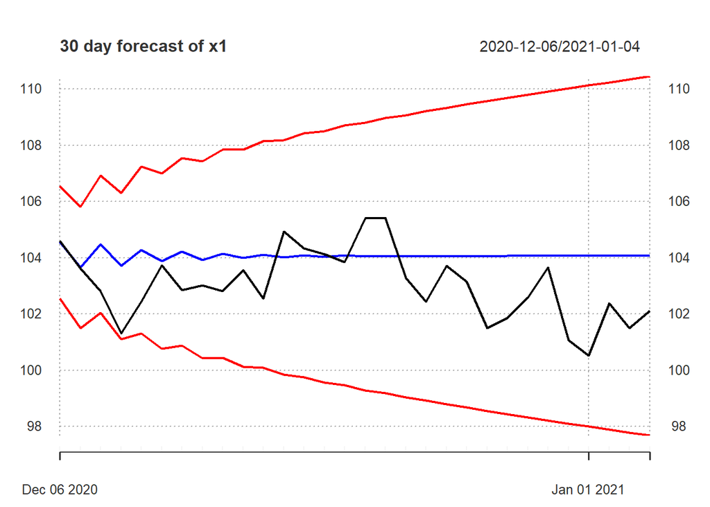

```r
plot(Data.fore ["2020-11/", c("x1", "x1_fore", "x1_lower", "x1_upper")],
     major.ticks = "years",
     grid.ticks.on = "years",
     grid.ticks.lty = 3,
     main = "30 day forecast of x1",
     col = c("black", "blue", "red", "red"))
```

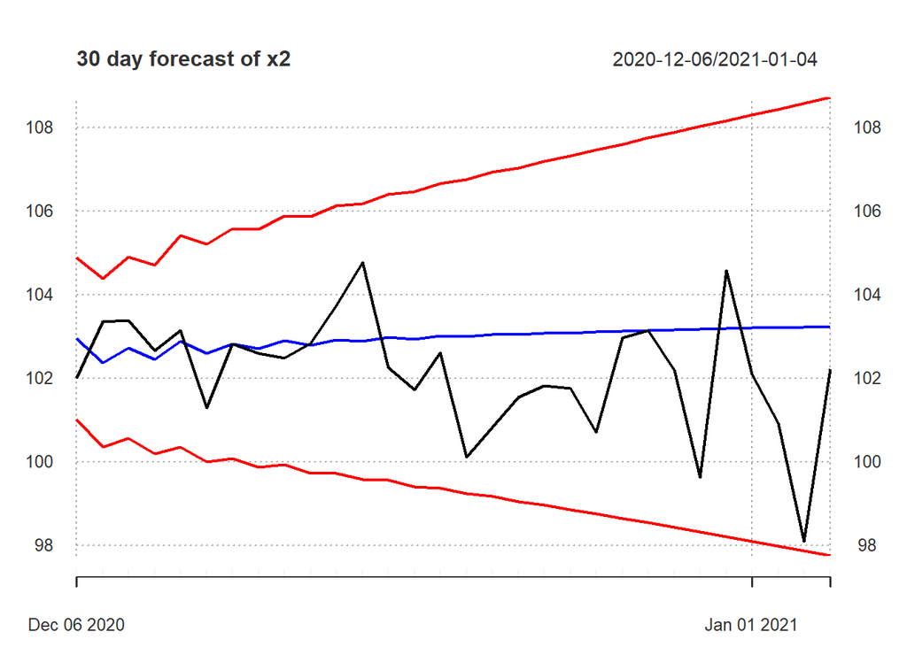

```r
plot(Data.fore ["2020-11/", c("x2", "x2_fore", "x2_lower", "x2_upper")],
     major.ticks = "years",
     grid.ticks.on = "years",
     grid.ticks.lty = 3,
     main = "30 day forecast of x2",
     col = c("black", "blue", "red", "red"))
```

##5.4. Calculate forecast accuracy measures

Extract the out-of-sample data to evaluate:

```r
Data.fore2 <- Data.fore[,-30]
```

```r
Data.fore2$mae.x1   <-  abs(Data.fore2$x1 - Data.fore2$x1_fore)
Data.fore2$mse.x1   <-  (Data.fore2$x1 - Data.fore2$x1_fore)^2
Data.fore2$mape.x1  <-  abs(Data.fore2$x1 - Data.fore2$x1_fore)/Data.fore2$x1
Data.fore2$amape.x1 <-  abs(Data.fore2$x1 - Data.fore2$x1_fore)/(Data.fore2$x1 + Data.fore2$x1_fore)
```

```r
Data.fore2$mae.x2   <-  abs(Data.fore2$x2 - Data.fore2$x2_fore)
Data.fore2$mse.x2   <-  (Data.fore2$x2 - Data.fore2$x2_fore)^2
Data.fore2$mape.x2  <-  abs(Data.fore2$x2 - Data.fore2$x2_fore)/Data.fore2$x2
Data.fore2$amape.x2 <-  abs(Data.fore2$x2 - Data.fore2$x2_fore)/(Data.fore2$x2 + Data.fore2$x2_fore)
```

and calculate its averages

```r
VECM_x1 <- colMeans(Data.fore2[, c("mae.x1",
                      "mse.x1",
                      "mape.x1",
                      "amape.x1")], na.rm = TRUE)
```

```r
VECM_x2 <- colMeans(Data.fore2[, c("mae.x2",
                      "mse.x2",
                      "mape.x2",
                      "amape.x2")], na.rm = TRUE)
```

#6. Comparing VECM model’s forecasts with ARIMAs:

```r
result <- rbind(ARIMA_x1,VECM_x1, ARIMA_x2,VECM_x2)

result %>%
  knitr::kable(digits = 4) %>%
  kableExtra::kable_styling(full_width = F,
                            bootstrap_options = c("striped",
                                                  "hover",
                                                  "condensed"))
```

|  | mae | mse | mape | amape |
| --- | --- | --- | --- | --- |
| ARIMA_x1 | 1.2821 | 2.4851 | 0.0125 | 0.0062 |
| VECM_x1 | 1.3003 | 2.5523 | 0.0127 | 0.0063 |
| ARIMA_x2 | 1.0373 | 1.9546 | 0.0102 | 0.0051 |
| VECM_x2 | 1.2398 | 2.8253 | 0.0123 | 0.0061 |

Conclusion: The forecasts from ARIMA model outperforms that of VECM.